# BSchmidt_Project_4

### Neural Network with SGD Optimizer

```python
# Adjusting the random number seed to receive same output each iteration
backend.clear_session()
np.random.seed(2)
random.seed(2)
tf.random.set_seed(2)
```

```python
# Initializing the neural network
model_0 = Sequential()

# Adding the input layer with 64 neurons and relu as activation function
model_0.add(Dense(64, activation='relu', input_dim = X_train.shape[1]))

# Add a hidden layer
model_0.add(Dense(32, activation='relu'))

# Add output layer
model_0.add(Dense(1, activation = 'sigmoid'))
```

```python
# Establish SGD as the optimizer.
optimizer = tf.keras.optimizers.SGD(0.001)
metric = keras.metrics.Recall()
```

```python
# Compile model with binary cross entropy as loss function and recall as the metric.
model_0.compile(loss='binary_crossentropy',optimizer=optimizer,metrics=[metric])
```

```python
model_0.summary()
```

```
Model: "sequential"
```

```
┏━━━━━━━━━━━━━━━━━━━━━━━━━━━━━━━━━━━━━━┳━━━━━━━━━━━━━━━━━━━━━━━━━━━━━┳━━━━━━━━━━━━━━━━━┓
┃ Layer (type)                         ┃ Output Shape                ┃         Param # ┃
┡━━━━━━━━━━━━━━━━━━━━━━━━━━━━━━━━━━━━━━╇━━━━━━━━━━━━━━━━━━━━━━━━━━━━━╇━━━━━━━━━━━━━━━━━┩
│ dense (Dense)                        │ (None, 64)                  │             768 │
├──────────────────────────────────────┼─────────────────────────────┼─────────────────┤
│ dense_1 (Dense)                      │ (None, 32)                  │           2,080 │
├──────────────────────────────────────┼─────────────────────────────┼─────────────────┤
│ dense_2 (Dense)                      │ (None, 1)                   │              33 │
└──────────────────────────────────────┴─────────────────────────────┴─────────────────┘
```

```
 Total params: 2,881 (11.25 KB)
```

```
 Trainable params: 2,881 (11.25 KB)
```

```
 Non-trainable params: 0 (0.00 B)
```

```python
# Fit the ANN
history_0 = model_0.fit(
    X_train, y_train,
    batch_size=64,    # 64 is the batch size
    validation_data=(X_val,y_val),
    epochs=100,    # 100 epochs/iterations
    verbose=1
)
```

```
100/100 ━━━━━━━━━━━━━━━━━━━━ 3s 12ms/step - loss: 0.6460 - recall: 0.1580 - val_loss: 0.6093 - val_recall: 0.0368
100/100 ━━━━━━━━━━━━━━━━━━━━ 0s 3ms/step - loss: 0.6071 - recall: 0.0188 - val_loss: 0.5795 - val_recall: 0.0000e+00
100/100 ━━━━━━━━━━━━━━━━━━━━ 1s 3ms/step - loss: 0.5798 - recall: 0.0020 - val_loss: 0.5581 - val_recall: 0.0000e+00
100/100 ━━━━━━━━━━━━━━━━━━━━ 0s 2ms/step - loss: 0.5601 - recall: 0.0016 - val_loss: 0.5426 - val_recall: 0.0000e+00
100/100 ━━━━━━━━━━━━━━━━━━━━ 0s 2ms/step - loss: 0.5458 - recall: 0.0000e+00 - val_loss: 0.5310 - val_recall: 0.0000e+00
100/100 ━━━━━━━━━━━━━━━━━━━━ 0s 2ms/step - loss: 0.5351 - recall: 0.0000e+00 - val_loss: 0.5224 - val_recall: 0.0000e+00
100/100 ━━━━━━━━━━━━━━━━━━━━ 0s 2ms/step - loss: 0.5271 - recall: 0.0000e+00 - val_loss: 0.5158 - val_recall: 0.0000e+00
100/100 ━━━━━━━━━━━━━━━━━━━━ 0s 2ms/step - loss: 0.5209 - recall: 0.0000e+00 - val_loss: 0.5106 - val_recall: 0.0000e+00
100/100 ━━━━━━━━━━━━━━━━━━━━ 0s 2ms/step - loss: 0.5159 - recall: 0.0000e+00 - val_loss: 0.5064 - val_recall: 0.0000e+00
100/100 ━━━━━━━━━━━━━━━━━━━━ 0s 2ms/step - loss: 0.5119 - recall: 0.0000e+00 - val_loss: 0.5029 - val_recall: 0.0000e+00
100/100 ━━━━━━━━━━━━━━━━━━━━ 0s 2ms/step - loss: 0.5085 - recall: 0.0000e+00 - val_loss: 0.5000 - val_recall: 0.0000e+00
100/100 ━━━━━━━━━━━━━━━━━━━━ 0s 2ms/step - loss: 0.5055 - recall: 0.0000e+00 - val_loss: 0.4974 - val_recall: 0.0000e+00
100/100 ━━━━━━━━━━━━━━━━━━━━ 0s 2ms/step - loss: 0.5029 - recall: 0.0000e+00 - val_loss: 0.4951 - val_recall: 0.0000e+00
100/100 ━━━━━━━━━━━━━━━━━━━━ 0s 2ms/step - loss: 0.5005 - recall: 0.0000e+00 - val_loss: 0.4931 - val_recall: 0.0000e+00
100/100 ━━━━━━━━━━━━━━━━━━━━ 0s 2ms/step - loss: 0.4983 - recall: 0.0000e+00 - val_loss: 0.4912 - val_recall: 0.0000e+00
100/100 ━━━━━━━━━━━━━━━━━━━━ 0s 2ms/step - loss: 0.4962 - recall: 0.0000e+00 - val_loss: 0.4894 - val_recall: 0.0000e+00
100/100 ━━━━━━━━━━━━━━━━━━━━ 0s 2ms/step - loss: 0.4943 - recall: 0.0000e+00 - val_loss: 0.4877 - val_recall: 0.0000e+00
100/100 ━━━━━━━━━━━━━━━━━━━━ 0s 2ms/step - loss: 0.4924 - recall: 0.0000e+00 - val_loss: 0.4861 - val_recall: 0.0000e+00
100/100 ━━━━━━━━━━━━━━━━━━━━ 0s 2ms/step - loss: 0.4906 - recall: 0.0000e+00 - val_loss: 0.4846 - val_recall: 0.0000e+00
100/100 ━━━━━━━━━━━━━━━━━━━━ 0s 2ms/step - loss: 0.4889 - recall: 0.0000e+00 - val_loss: 0.4831 - val_recall: 0.0000e+00
100/100 ━━━━━━━━━━━━━━━━━━━━ 0s 2ms/step - loss: 0.4872 - recall: 0.0000e+00 - val_loss: 0.4817 - val_recall: 0.0000e+00
100/100 ━━━━━━━━━━━━━━━━━━━━ 0s 2ms/step - loss: 0.4856 - recall: 0.0000e+00 - val_loss: 0.4804 - val_recall: 0.0000e+00
100/100 ━━━━━━━━━━━━━━━━━━━━ 0s 2ms/step - loss: 0.4840 - recall: 0.0000e+00 - val_loss: 0.4791 - val_recall: 0.0000e+00
100/100 ━━━━━━━━━━━━━━━━━━━━ 0s 2ms/step - loss: 0.4825 - recall: 0.0000e+00 - val_loss: 0.4778 - val_recall: 0.0000e+00
100/100 ━━━━━━━━━━━━━━━━━━━━ 0s 2ms/step - loss: 0.4810 - recall: 0.0000e+00 - val_loss: 0.4766 - val_recall: 0.0000e+00
100/100 ━━━━━━━━━━━━━━━━━━━━ 0s 2ms/step - loss: 0.4796 - recall: 0.0000e+00 - val_loss: 0.4754 - val_recall: 0.0000e+00
100/100 ━━━━━━━━━━━━━━━━━━━━ 0s 2ms/step - loss: 0.4782 - recall: 0.0000e+00 - val_loss: 0.4742 - val_recall: 0.0000e+00
100/100 ━━━━━━━━━━━━━━━━━━━━ 0s 2ms/step - loss: 0.4768 - recall: 0.0000e+00 - val_loss: 0.4731 - val_recall: 0.0000e+00
100/100 ━━━━━━━━━━━━━━━━━━━━ 0s 2ms/step - loss: 0.4755 - recall: 0.0014 - val_loss: 0.4720 - val_recall: 0.0000e+00
100/100 ━━━━━━━━━━━━━━━━━━━━ 0s 2ms/step - loss: 0.4742 - recall: 0.0014 - val_loss: 0.4710 - val_recall: 0.0000e+00
100/100 ━━━━━━━━━━━━━━━━━━━━ 0s 2ms/step - loss: 0.4729 - recall: 0.0014 - val_loss: 0.4699 - val_recall: 0.0000e+00
100/100 ━━━━━━━━━━━━━━━━━━━━ 0s 2ms/step - loss: 0.4716 - recall: 0.0015 - val_loss: 0.4689 - val_recall: 0.0000e+00
100/100 ━━━━━━━━━━━━━━━━━━━━ 0s 2ms/step - loss: 0.4704 - recall: 0.0015 - val_loss: 0.4680 - val_recall: 0.0000e+00
100/100 ━━━━━━━━━━━━━━━━━━━━ 0s 2ms/step - loss: 0.4693 - recall: 0.0015 - val_loss: 0.4670 - val_recall: 0.0000e+00
100/100 ━━━━━━━━━━━━━━━━━━━━ 0s 2ms/step - loss: 0.4681 - recall: 0.0015 - val_loss: 0.4661 - val_recall: 0.0031
100/100 ━━━━━━━━━━━━━━━━━━━━ 0s 2ms/step - loss: 0.4670 - recall: 0.0015 - val_loss: 0.4652 - val_recall: 0.0031
100/100 ━━━━━━━━━━━━━━━━━━━━ 0s 2ms/step - loss: 0.4659 - recall: 0.0015 - val_loss: 0.4643 - val_recall: 0.0031
100/100 ━━━━━━━━━━━━━━━━━━━━ 0s 2ms/step - loss: 0.4648 - recall: 0.0015 - val_loss: 0.4635 - val_recall: 0.0031
100/100 ━━━━━━━━━━━━━━━━━━━━ 0s 2ms/step - loss: 0.4638 - recall: 0.0035 - val_loss: 0.4627 - val_recall: 0.0031
100/100 ━━━━━━━━━━━━━━━━━━━━ 0s 2ms/step - loss: 0.4628 - recall: 0.0035 - val_loss: 0.4618 - val_recall: 0.0031
```

[output cut: 45 more lines]

```
100/100 ━━━━━━━━━━━━━━━━━━━━ 0s 2ms/step - loss: 0.4343 - recall: 0.1078 - val_loss: 0.4406 - val_recall: 0.0675
100/100 ━━━━━━━━━━━━━━━━━━━━ 0s 2ms/step - loss: 0.4339 - recall: 0.1088 - val_loss: 0.4403 - val_recall: 0.0706
100/100 ━━━━━━━━━━━━━━━━━━━━ 0s 3ms/step - loss: 0.4336 - recall: 0.1109 - val_loss: 0.4401 - val_recall: 0.0736
100/100 ━━━━━━━━━━━━━━━━━━━━ 0s 3ms/step - loss: 0.4332 - recall: 0.1117 - val_loss: 0.4399 - val_recall: 0.0736
100/100 ━━━━━━━━━━━━━━━━━━━━ 1s 3ms/step - loss: 0.4329 - recall: 0.1128 - val_loss: 0.4397 - val_recall: 0.0736
100/100 ━━━━━━━━━━━━━━━━━━━━ 1s 3ms/step - loss: 0.4326 - recall: 0.1139 - val_loss: 0.4394 - val_recall: 0.0736
100/100 ━━━━━━━━━━━━━━━━━━━━ 0s 3ms/step - loss: 0.4323 - recall: 0.1143 - val_loss: 0.4392 - val_recall: 0.0736
100/100 ━━━━━━━━━━━━━━━━━━━━ 1s 3ms/step - loss: 0.4319 - recall: 0.1173 - val_loss: 0.4390 - val_recall: 0.0828
100/100 ━━━━━━━━━━━━━━━━━━━━ 1s 2ms/step - loss: 0.4316 - recall: 0.1181 - val_loss: 0.4388 - val_recall: 0.0859
100/100 ━━━━━━━━━━━━━━━━━━━━ 0s 2ms/step - loss: 0.4313 - recall: 0.1221 - val_loss: 0.4386 - val_recall: 0.0859
100/100 ━━━━━━━━━━━━━━━━━━━━ 0s 2ms/step - loss: 0.4310 - recall: 0.1235 - val_loss: 0.4385 - val_recall: 0.0859
100/100 ━━━━━━━━━━━━━━━━━━━━ 0s 2ms/step - loss: 0.4307 - recall: 0.1238 - val_loss: 0.4383 - val_recall: 0.0890
100/100 ━━━━━━━━━━━━━━━━━━━━ 0s 2ms/step - loss: 0.4304 - recall: 0.1243 - val_loss: 0.4381 - val_recall: 0.0890
100/100 ━━━━━━━━━━━━━━━━━━━━ 0s 2ms/step - loss: 0.4301 - recall: 0.1269 - val_loss: 0.4379 - val_recall: 0.0890
100/100 ━━━━━━━━━━━━━━━━━━━━ 0s 2ms/step - loss: 0.4298 - recall: 0.1277 - val_loss: 0.4377 - val_recall: 0.0920
```

**Loss function**

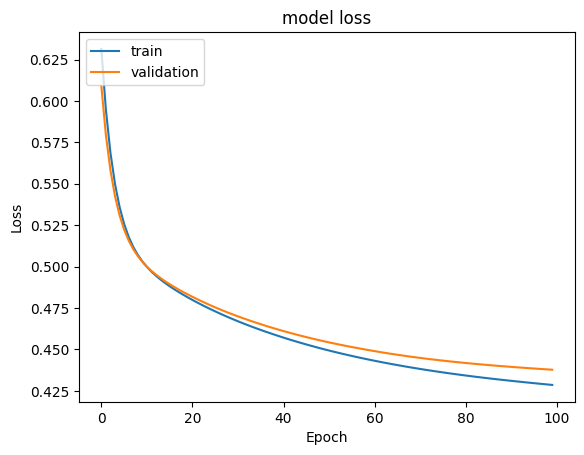

```python
# Plot Train Loss vs Validation Loss
plt.plot(history_0.history['loss'])
plt.plot(history_0.history['val_loss'])
plt.title('model loss')
plt.ylabel('Loss')
plt.xlabel('Epoch')
plt.legend(['train', 'validation'], loc='upper left')
plt.show()
```

**Recall**

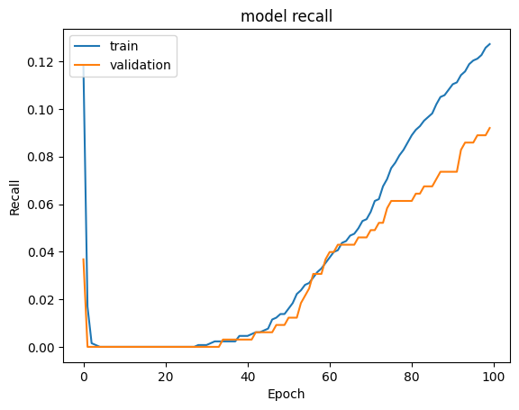

```python
# Plot Train recall vs Validation recall
plt.plot(history_0.history['recall'])
plt.plot(history_0.history['val_recall'])
plt.title('model recall')
plt.ylabel('Recall')
plt.xlabel('Epoch')
plt.legend(['train', 'validation'], loc='upper left')
plt.show()
```

```python
# Predict the results using best as a threshold
y_train_pred = model_0.predict(X_train)
y_train_pred = (y_train_pred > 0.5)
y_train_pred
```

```
200/200 ━━━━━━━━━━━━━━━━━━━━ 0s 1ms/step
```

```
array([[False],
       [False],
       [False],
       ...,
       [False],
       [False],
       [False]])
```

```python
# Predict the results using best as a threshold & use validation set to predict
y_val_pred = model_0.predict(X_val)
y_val_pred = (y_val_pred > 0.5)
y_val_pred
```

```
50/50 ━━━━━━━━━━━━━━━━━━━━ 0s 1ms/step
```

```
array([[False],
       [False],
       [False],
       ...,
       [False],
       [False],
       [False]])
```

```python
# Establish model name
model_name = "NN with SGD"
train_metric_df.loc[model_name] = recall_score(y_train, y_train_pred)
valid_metric_df.loc[model_name] = recall_score(y_val, y_val_pred)
```

**Classification report**

```python
# Show classification report for the train set
cr = classification_report(y_train, y_train_pred)
print(cr)
```

```
              precision    recall  f1-score   support

           0       0.81      0.98      0.89      5096
           1       0.65      0.13      0.21      1304

    accuracy                           0.81      6400
   macro avg       0.73      0.56      0.55      6400
weighted avg       0.78      0.81      0.75      6400
```

```python
# Show classification report for validation set
cr=classification_report(y_val, y_val_pred)
print(cr)
```

```
              precision    recall  f1-score   support

           0       0.81      0.98      0.89      1274
           1       0.59      0.09      0.16       326

    accuracy                           0.80      1600
   macro avg       0.70      0.54      0.52      1600
weighted avg       0.76      0.80      0.74      1600
```

**Confusion matrix**

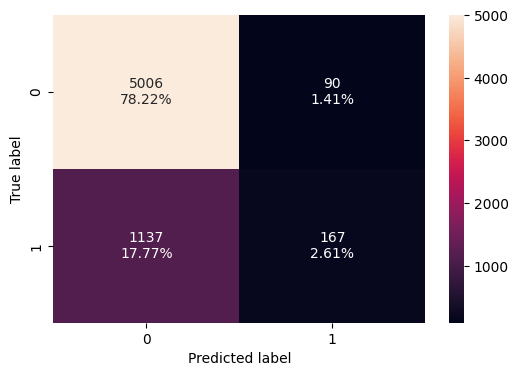

```python
# Show train confusion matrix
make_confusion_matrix(y_train, y_train_pred)
```

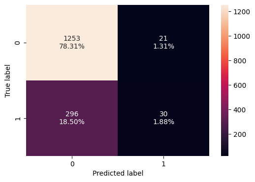

```python
# Show validation confusion matrix
make_confusion_matrix(y_val, y_val_pred)
```

## Model Performance Improvement

### Neural Network with Adam Optimizer

```python
# Adjusting the random number seed to receive same output each iteration
backend.clear_session()
np.random.seed(2)
random.seed(2)
tf.random.set_seed(2)
```

```python
# Initializing the neural network
model_1 = Sequential()
# Add input layer with RELU as activation function
model_1.add(Dense(16,activation='relu',input_dim = X_train.shape[1]))
# Add a hidden layer with RELU as activation function
model_1.add(Dense(8,activation='relu'))
# Add a output layer with RELU as activation function
model_1.add(Dense(1, activation = 'relu'))
```

```python
# Set ADAM as the optimizer & Recall as the metric
optimizer = tf.keras.optimizers.Adam()
metric = keras.metrics.Recall()
```

```python
# Compile the model with binary cross entropy as loss function and recall as the metric
model_1.compile(loss='binary_crossentropy',optimizer=optimizer,metrics=[metric])
```

```python
model_1.summary()
```

```
Model: "sequential"
```

```
┏━━━━━━━━━━━━━━━━━━━━━━━━━━━━━━━━━━━━━━┳━━━━━━━━━━━━━━━━━━━━━━━━━━━━━┳━━━━━━━━━━━━━━━━━┓
┃ Layer (type)                         ┃ Output Shape                ┃         Param # ┃
┡━━━━━━━━━━━━━━━━━━━━━━━━━━━━━━━━━━━━━━╇━━━━━━━━━━━━━━━━━━━━━━━━━━━━━╇━━━━━━━━━━━━━━━━━┩
│ dense (Dense)                        │ (None, 16)                  │             192 │
├──────────────────────────────────────┼─────────────────────────────┼─────────────────┤
│ dense_1 (Dense)                      │ (None, 8)                   │             136 │
├──────────────────────────────────────┼─────────────────────────────┼─────────────────┤
│ dense_2 (Dense)                      │ (None, 1)                   │               9 │
└──────────────────────────────────────┴─────────────────────────────┴─────────────────┘
```

```
 Total params: 337 (1.32 KB)
```

```
 Trainable params: 337 (1.32 KB)
```

```
 Non-trainable params: 0 (0.00 B)
```

```python
# Fit the ANN
history_1 = model_1.fit(
    X_train,y_train,
    batch_size=64, # 64 is the batch size
    validation_data=(X_val,y_val),
    epochs=100, # 100 is the number of epochs/iterations
    verbose=1
)
```

```
100/100 ━━━━━━━━━━━━━━━━━━━━ 3s 9ms/step - loss: 0.9303 - recall: 0.2004 - val_loss: 0.5483 - val_recall: 0.0859
100/100 ━━━━━━━━━━━━━━━━━━━━ 0s 2ms/step - loss: 0.5187 - recall: 0.0961 - val_loss: 0.4905 - val_recall: 0.0859
100/100 ━━━━━━━━━━━━━━━━━━━━ 0s 2ms/step - loss: 0.4826 - recall: 0.1051 - val_loss: 0.4720 - val_recall: 0.0920
100/100 ━━━━━━━━━━━━━━━━━━━━ 0s 2ms/step - loss: 0.4723 - recall: 0.1139 - val_loss: 0.4631 - val_recall: 0.0859
100/100 ━━━━━━━━━━━━━━━━━━━━ 0s 2ms/step - loss: 0.4589 - recall: 0.1171 - val_loss: 0.4550 - val_recall: 0.1012
100/100 ━━━━━━━━━━━━━━━━━━━━ 0s 3ms/step - loss: 0.4486 - recall: 0.1631 - val_loss: 0.4617 - val_recall: 0.2393
100/100 ━━━━━━━━━━━━━━━━━━━━ 0s 2ms/step - loss: 0.4519 - recall: 0.1927 - val_loss: 0.4459 - val_recall: 0.1012
100/100 ━━━━━━━━━━━━━━━━━━━━ 0s 2ms/step - loss: 0.4420 - recall: 0.1259 - val_loss: 0.4506 - val_recall: 0.1135
100/100 ━━━━━━━━━━━━━━━━━━━━ 0s 2ms/step - loss: 0.4359 - recall: 0.1614 - val_loss: 0.4481 - val_recall: 0.1196
100/100 ━━━━━━━━━━━━━━━━━━━━ 0s 2ms/step - loss: 0.4309 - recall: 0.1967 - val_loss: 0.4457 - val_recall: 0.1350
100/100 ━━━━━━━━━━━━━━━━━━━━ 0s 2ms/step - loss: 0.4271 - recall: 0.2103 - val_loss: 0.4436 - val_recall: 0.1442
100/100 ━━━━━━━━━━━━━━━━━━━━ 0s 2ms/step - loss: 0.4234 - recall: 0.2228 - val_loss: 0.4413 - val_recall: 0.1656
100/100 ━━━━━━━━━━━━━━━━━━━━ 0s 3ms/step - loss: 0.4203 - recall: 0.2332 - val_loss: 0.4328 - val_recall: 0.1779
100/100 ━━━━━━━━━━━━━━━━━━━━ 0s 3ms/step - loss: 0.4175 - recall: 0.2416 - val_loss: 0.4375 - val_recall: 0.1810
100/100 ━━━━━━━━━━━━━━━━━━━━ 0s 3ms/step - loss: 0.4149 - recall: 0.2486 - val_loss: 0.4359 - val_recall: 0.1840
100/100 ━━━━━━━━━━━━━━━━━━━━ 1s 3ms/step - loss: 0.4124 - recall: 0.2527 - val_loss: 0.4347 - val_recall: 0.1933
100/100 ━━━━━━━━━━━━━━━━━━━━ 0s 3ms/step - loss: 0.4101 - recall: 0.2635 - val_loss: 0.4337 - val_recall: 0.2117
100/100 ━━━━━━━━━━━━━━━━━━━━ 0s 4ms/step - loss: 0.4075 - recall: 0.2758 - val_loss: 0.4252 - val_recall: 0.2147
100/100 ━━━━━━━━━━━━━━━━━━━━ 0s 3ms/step - loss: 0.4052 - recall: 0.2747 - val_loss: 0.4315 - val_recall: 0.2209
100/100 ━━━━━━━━━━━━━━━━━━━━ 1s 3ms/step - loss: 0.4029 - recall: 0.2807 - val_loss: 0.4307 - val_recall: 0.2331
100/100 ━━━━━━━━━━━━━━━━━━━━ 1s 2ms/step - loss: 0.4006 - recall: 0.2906 - val_loss: 0.4283 - val_recall: 0.2454
100/100 ━━━━━━━━━━━━━━━━━━━━ 0s 2ms/step - loss: 0.3986 - recall: 0.3092 - val_loss: 0.4257 - val_recall: 0.2423
100/100 ━━━━━━━━━━━━━━━━━━━━ 0s 2ms/step - loss: 0.3968 - recall: 0.3115 - val_loss: 0.4254 - val_recall: 0.2546
100/100 ━━━━━━━━━━━━━━━━━━━━ 0s 2ms/step - loss: 0.3951 - recall: 0.3199 - val_loss: 0.4300 - val_recall: 0.2607
100/100 ━━━━━━━━━━━━━━━━━━━━ 0s 2ms/step - loss: 0.3933 - recall: 0.3308 - val_loss: 0.4296 - val_recall: 0.2607
100/100 ━━━━━━━━━━━━━━━━━━━━ 0s 2ms/step - loss: 0.3914 - recall: 0.3450 - val_loss: 0.4294 - val_recall: 0.2730
100/100 ━━━━━━━━━━━━━━━━━━━━ 0s 3ms/step - loss: 0.3894 - recall: 0.3499 - val_loss: 0.4298 - val_recall: 0.2791
100/100 ━━━━━━━━━━━━━━━━━━━━ 0s 2ms/step - loss: 0.3876 - recall: 0.3563 - val_loss: 0.4324 - val_recall: 0.2883
100/100 ━━━━━━━━━━━━━━━━━━━━ 0s 2ms/step - loss: 0.3853 - recall: 0.3593 - val_loss: 0.4360 - val_recall: 0.2914
100/100 ━━━━━━━━━━━━━━━━━━━━ 0s 2ms/step - loss: 0.3834 - recall: 0.3633 - val_loss: 0.4417 - val_recall: 0.2945
100/100 ━━━━━━━━━━━━━━━━━━━━ 0s 2ms/step - loss: 0.3813 - recall: 0.3674 - val_loss: 0.4409 - val_recall: 0.2853
100/100 ━━━━━━━━━━━━━━━━━━━━ 0s 2ms/step - loss: 0.3789 - recall: 0.3789 - val_loss: 0.4397 - val_recall: 0.2914
100/100 ━━━━━━━━━━━━━━━━━━━━ 0s 2ms/step - loss: 0.3770 - recall: 0.3839 - val_loss: 0.4381 - val_recall: 0.2945
100/100 ━━━━━━━━━━━━━━━━━━━━ 0s 2ms/step - loss: 0.3750 - recall: 0.3860 - val_loss: 0.4305 - val_recall: 0.2914
100/100 ━━━━━━━━━━━━━━━━━━━━ 0s 2ms/step - loss: 0.3735 - recall: 0.3875 - val_loss: 0.4299 - val_recall: 0.2883
100/100 ━━━━━━━━━━━━━━━━━━━━ 0s 2ms/step - loss: 0.3714 - recall: 0.3881 - val_loss: 0.4286 - val_recall: 0.2914
100/100 ━━━━━━━━━━━━━━━━━━━━ 0s 2ms/step - loss: 0.3704 - recall: 0.3871 - val_loss: 0.4281 - val_recall: 0.2945
100/100 ━━━━━━━━━━━━━━━━━━━━ 0s 2ms/step - loss: 0.3684 - recall: 0.3933 - val_loss: 0.4283 - val_recall: 0.3037
100/100 ━━━━━━━━━━━━━━━━━━━━ 0s 2ms/step - loss: 0.3673 - recall: 0.3959 - val_loss: 0.4275 - val_recall: 0.3037
100/100 ━━━━━━━━━━━━━━━━━━━━ 0s 2ms/step - loss: 0.3657 - recall: 0.4043 - val_loss: 0.4265 - val_recall: 0.3067
```

[output cut: 45 more lines]

```
100/100 ━━━━━━━━━━━━━━━━━━━━ 0s 2ms/step - loss: 0.3346 - recall: 0.4730 - val_loss: 0.4720 - val_recall: 0.3681
100/100 ━━━━━━━━━━━━━━━━━━━━ 0s 2ms/step - loss: 0.3342 - recall: 0.4756 - val_loss: 0.4719 - val_recall: 0.3681
100/100 ━━━━━━━━━━━━━━━━━━━━ 0s 2ms/step - loss: 0.3338 - recall: 0.4733 - val_loss: 0.4711 - val_recall: 0.3681
100/100 ━━━━━━━━━━━━━━━━━━━━ 0s 2ms/step - loss: 0.3336 - recall: 0.4783 - val_loss: 0.4710 - val_recall: 0.3681
100/100 ━━━━━━━━━━━━━━━━━━━━ 0s 2ms/step - loss: 0.3333 - recall: 0.4783 - val_loss: 0.4707 - val_recall: 0.3650
100/100 ━━━━━━━━━━━━━━━━━━━━ 0s 2ms/step - loss: 0.3328 - recall: 0.4797 - val_loss: 0.4724 - val_recall: 0.3681
100/100 ━━━━━━━━━━━━━━━━━━━━ 0s 2ms/step - loss: 0.3325 - recall: 0.4800 - val_loss: 0.4723 - val_recall: 0.3681
100/100 ━━━━━━━━━━━━━━━━━━━━ 0s 2ms/step - loss: 0.3322 - recall: 0.4814 - val_loss: 0.4701 - val_recall: 0.3681
100/100 ━━━━━━━━━━━━━━━━━━━━ 0s 2ms/step - loss: 0.3319 - recall: 0.4771 - val_loss: 0.4707 - val_recall: 0.3650
100/100 ━━━━━━━━━━━━━━━━━━━━ 0s 2ms/step - loss: 0.3319 - recall: 0.4822 - val_loss: 0.4708 - val_recall: 0.3712
100/100 ━━━━━━━━━━━━━━━━━━━━ 0s 2ms/step - loss: 0.3315 - recall: 0.4817 - val_loss: 0.4720 - val_recall: 0.3620
100/100 ━━━━━━━━━━━━━━━━━━━━ 0s 2ms/step - loss: 0.3316 - recall: 0.4833 - val_loss: 0.4703 - val_recall: 0.3681
100/100 ━━━━━━━━━━━━━━━━━━━━ 0s 2ms/step - loss: 0.3311 - recall: 0.4787 - val_loss: 0.4710 - val_recall: 0.3620
100/100 ━━━━━━━━━━━━━━━━━━━━ 0s 2ms/step - loss: 0.3311 - recall: 0.4847 - val_loss: 0.4716 - val_recall: 0.3620
100/100 ━━━━━━━━━━━━━━━━━━━━ 0s 2ms/step - loss: 0.3304 - recall: 0.4836 - val_loss: 0.4723 - val_recall: 0.3589
```

**Loss function**

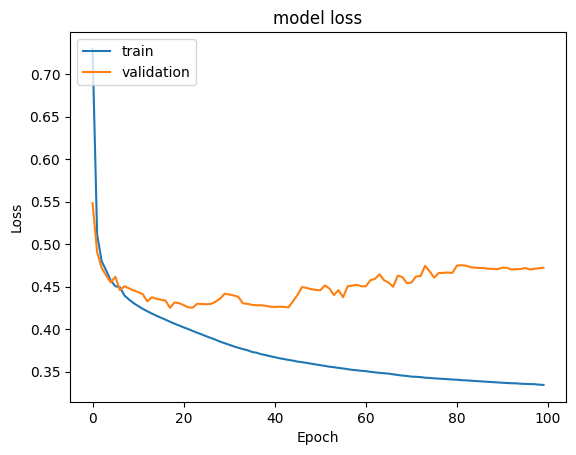

```python
# Plot Train Loss vs Validation Loss
plt.plot(history_1.history['loss'])
plt.plot(history_1.history['val_loss'])
plt.title('model loss')
plt.ylabel('Loss')
plt.xlabel('Epoch')
plt.legend(['train', 'validation'], loc='upper left')
plt.show()
```

**Recall**

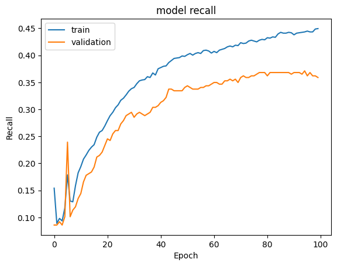

```python
# Plot Train recall vs Validation recall
plt.plot(history_1.history['recall'])
plt.plot(history_1.history['val_recall'])
plt.title('model recall')
plt.ylabel('Recall')
plt.xlabel('Epoch')
plt.legend(['train', 'validation'], loc='upper left')
plt.show()
```

```python
# Predict the results using 0.5 as the threshold
y_train_pred = model_1.predict(X_train)
y_train_pred = (y_train_pred > 0.5)
y_train_pred
```

```
200/200 ━━━━━━━━━━━━━━━━━━━━ 1s 2ms/step
```

```
array([[False],
       [False],
       [False],
       ...,
       [False],
       [False],
       [False]])
```

```python
# Predict the results using 0.5 as the threshold
y_val_pred = model_1.predict(X_val)
y_val_pred = (y_val_pred > 0.5)
y_val_pred
```

```
50/50 ━━━━━━━━━━━━━━━━━━━━ 0s 2ms/step
```

```
array([[False],
       [False],
       [False],
       ...,
       [False],
       [False],
       [False]])
```

```python
# Establish model name
model_name = "NN with Adam"
train_metric_df.loc[model_name] = recall_score(y_train,y_train_pred)
valid_metric_df.loc[model_name] = recall_score(y_val,y_val_pred)
```

**Classification report**

```python
# Show train classification report
cr=classification_report(y_train,y_train_pred)
print(cr)
```

```
              precision    recall  f1-score   support

           0       0.87      0.96      0.92      5096
           1       0.76      0.45      0.56      1304

    accuracy                           0.86      6400
   macro avg       0.82      0.71      0.74      6400
weighted avg       0.85      0.86      0.84      6400
```

```python
# Show validation classification report
cr=classification_report(y_val,y_val_pred)
print(cr)
```

```
              precision    recall  f1-score   support

           0       0.86      0.97      0.91      1274
           1       0.75      0.36      0.49       326

    accuracy                           0.84      1600
   macro avg       0.80      0.66      0.70      1600
weighted avg       0.83      0.84      0.82      1600
```

**Confusion matrix**

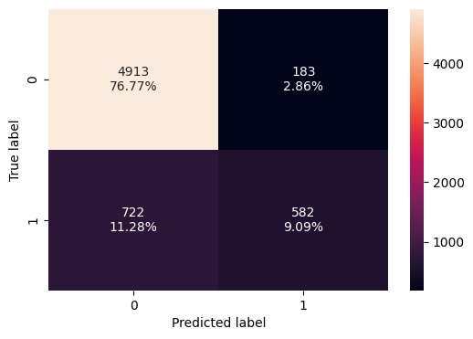

```python
# Show train confusion matrix
make_confusion_matrix(y_train, y_train_pred)
```

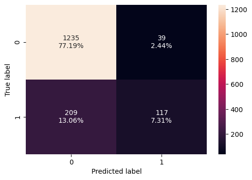

```python
# Show validation confusion matrix
make_confusion_matrix(y_val,y_val_pred)
```

### Neural Network with Adam Optimizer and Dropout

```python
# Adjusting the random number seed to receive same output each iteration
backend.clear_session()
np.random.seed(2)
random.seed(2)
tf.random.set_seed(2)
```

```python
# Initializing the neural network
model_2 = Sequential()
# Add input layer
model_2.add(Dense(32,activation='relu',input_dim = X_train.shape[1]))
# Add dropout ratio of 0.2
model_2.add(Dropout(0.2))
# Add a hidden layer
model_2.add(Dense(32,activation='relu'))
# Add a hidden layer
model_2.add(Dense(16,activation='relu'))
# Add dropout with ratio of 0.1
model_2.add(Dropout(0.1))
# Add a hidden layer
model_2.add(Dense(8,activation='relu'))
# Add output layer
model_2.add(Dense(1, activation = 'sigmoid'))
```

```python
# Set ADAM as the optimizer & Recall as metric
optimizer = tf.keras.optimizers.Adam()
metric = keras.metrics.Recall()
```

```python
# Compile the model with binary cross entropy as loss function and recall as the metric
model_2.compile(loss='binary_crossentropy',optimizer=optimizer,metrics=[metric])
```

```python
model_2.summary()
```

```
Model: "sequential"
```

```
┏━━━━━━━━━━━━━━━━━━━━━━━━━━━━━━━━━━━━━━┳━━━━━━━━━━━━━━━━━━━━━━━━━━━━━┳━━━━━━━━━━━━━━━━━┓
┃ Layer (type)                         ┃ Output Shape                ┃         Param # ┃
┡━━━━━━━━━━━━━━━━━━━━━━━━━━━━━━━━━━━━━━╇━━━━━━━━━━━━━━━━━━━━━━━━━━━━━╇━━━━━━━━━━━━━━━━━┩
│ dense (Dense)                        │ (None, 32)                  │             384 │
├──────────────────────────────────────┼─────────────────────────────┼─────────────────┤
│ dropout (Dropout)                    │ (None, 32)                  │               0 │
├──────────────────────────────────────┼─────────────────────────────┼─────────────────┤
│ dense_1 (Dense)                      │ (None, 32)                  │           1,056 │
├──────────────────────────────────────┼─────────────────────────────┼─────────────────┤
│ dense_2 (Dense)                      │ (None, 16)                  │             528 │
├──────────────────────────────────────┼─────────────────────────────┼─────────────────┤
│ dropout_1 (Dropout)                  │ (None, 16)                  │               0 │
├──────────────────────────────────────┼─────────────────────────────┼─────────────────┤
│ dense_3 (Dense)                      │ (None, 8)                   │             136 │
├──────────────────────────────────────┼─────────────────────────────┼─────────────────┤
│ dense_4 (Dense)                      │ (None, 1)                   │               9 │
└──────────────────────────────────────┴─────────────────────────────┴─────────────────┘
```

```
 Total params: 2,113 (8.25 KB)
```

```
 Trainable params: 2,113 (8.25 KB)
```

```
 Non-trainable params: 0 (0.00 B)
```

```python
#Fit the ANN
history_2 = model_2.fit(
    X_train,y_train,
    batch_size=32,  # 32 is the batch size
    epochs=100, # 100 number of epochs/iterations
    verbose=1,
    validation_data=(X_val,y_val)
)
```

```
200/200 ━━━━━━━━━━━━━━━━━━━━ 5s 6ms/step - loss: 0.5425 - recall: 0.1169 - val_loss: 0.4443 - val_recall: 0.0000e+00
200/200 ━━━━━━━━━━━━━━━━━━━━ 2s 2ms/step - loss: 0.4526 - recall: 0.0218 - val_loss: 0.4364 - val_recall: 0.0031
200/200 ━━━━━━━━━━━━━━━━━━━━ 1s 3ms/step - loss: 0.4395 - recall: 0.0483 - val_loss: 0.4312 - val_recall: 0.0337
200/200 ━━━━━━━━━━━━━━━━━━━━ 1s 2ms/step - loss: 0.4329 - recall: 0.1348 - val_loss: 0.4278 - val_recall: 0.0982
200/200 ━━━━━━━━━━━━━━━━━━━━ 1s 3ms/step - loss: 0.4274 - recall: 0.2102 - val_loss: 0.4203 - val_recall: 0.1902
200/200 ━━━━━━━━━━━━━━━━━━━━ 1s 3ms/step - loss: 0.4189 - recall: 0.2877 - val_loss: 0.4144 - val_recall: 0.2485
200/200 ━━━━━━━━━━━━━━━━━━━━ 1s 2ms/step - loss: 0.4174 - recall: 0.2985 - val_loss: 0.4124 - val_recall: 0.2393
200/200 ━━━━━━━━━━━━━━━━━━━━ 1s 3ms/step - loss: 0.4097 - recall: 0.3372 - val_loss: 0.4100 - val_recall: 0.3098
200/200 ━━━━━━━━━━━━━━━━━━━━ 0s 2ms/step - loss: 0.3991 - recall: 0.3599 - val_loss: 0.4041 - val_recall: 0.3221
200/200 ━━━━━━━━━━━━━━━━━━━━ 1s 3ms/step - loss: 0.3939 - recall: 0.3530 - val_loss: 0.4046 - val_recall: 0.3558
200/200 ━━━━━━━━━━━━━━━━━━━━ 1s 3ms/step - loss: 0.3936 - recall: 0.3815 - val_loss: 0.3997 - val_recall: 0.3098
200/200 ━━━━━━━━━━━━━━━━━━━━ 1s 3ms/step - loss: 0.3876 - recall: 0.3720 - val_loss: 0.3940 - val_recall: 0.3067
200/200 ━━━━━━━━━━━━━━━━━━━━ 1s 3ms/step - loss: 0.3902 - recall: 0.3701 - val_loss: 0.3939 - val_recall: 0.3252
200/200 ━━━━━━━━━━━━━━━━━━━━ 1s 3ms/step - loss: 0.3895 - recall: 0.3795 - val_loss: 0.3866 - val_recall: 0.3589
200/200 ━━━━━━━━━━━━━━━━━━━━ 1s 2ms/step - loss: 0.3824 - recall: 0.3844 - val_loss: 0.3819 - val_recall: 0.3344
200/200 ━━━━━━━━━━━━━━━━━━━━ 1s 3ms/step - loss: 0.3782 - recall: 0.3796 - val_loss: 0.3771 - val_recall: 0.3374
200/200 ━━━━━━━━━━━━━━━━━━━━ 1s 2ms/step - loss: 0.3770 - recall: 0.3928 - val_loss: 0.3724 - val_recall: 0.3865
200/200 ━━━━━━━━━━━━━━━━━━━━ 1s 3ms/step - loss: 0.3680 - recall: 0.4319 - val_loss: 0.3685 - val_recall: 0.3620
200/200 ━━━━━━━━━━━━━━━━━━━━ 1s 2ms/step - loss: 0.3688 - recall: 0.4102 - val_loss: 0.3639 - val_recall: 0.4018
200/200 ━━━━━━━━━━━━━━━━━━━━ 1s 3ms/step - loss: 0.3590 - recall: 0.4410 - val_loss: 0.3590 - val_recall: 0.4233
200/200 ━━━━━━━━━━━━━━━━━━━━ 1s 3ms/step - loss: 0.3556 - recall: 0.4463 - val_loss: 0.3570 - val_recall: 0.4233
200/200 ━━━━━━━━━━━━━━━━━━━━ 1s 3ms/step - loss: 0.3552 - recall: 0.4416 - val_loss: 0.3543 - val_recall: 0.4233
200/200 ━━━━━━━━━━━━━━━━━━━━ 1s 4ms/step - loss: 0.3562 - recall: 0.4424 - val_loss: 0.3551 - val_recall: 0.3896
200/200 ━━━━━━━━━━━━━━━━━━━━ 1s 3ms/step - loss: 0.3516 - recall: 0.4527 - val_loss: 0.3512 - val_recall: 0.4080
200/200 ━━━━━━━━━━━━━━━━━━━━ 1s 2ms/step - loss: 0.3500 - recall: 0.4463 - val_loss: 0.3487 - val_recall: 0.4233
200/200 ━━━━━━━━━━━━━━━━━━━━ 1s 2ms/step - loss: 0.3450 - recall: 0.4466 - val_loss: 0.3476 - val_recall: 0.4202
200/200 ━━━━━━━━━━━━━━━━━━━━ 1s 3ms/step - loss: 0.3482 - recall: 0.4567 - val_loss: 0.3481 - val_recall: 0.4479
200/200 ━━━━━━━━━━━━━━━━━━━━ 1s 3ms/step - loss: 0.3461 - recall: 0.4601 - val_loss: 0.3465 - val_recall: 0.4479
200/200 ━━━━━━━━━━━━━━━━━━━━ 1s 3ms/step - loss: 0.3444 - recall: 0.4587 - val_loss: 0.3467 - val_recall: 0.4325
200/200 ━━━━━━━━━━━━━━━━━━━━ 1s 2ms/step - loss: 0.3501 - recall: 0.4392 - val_loss: 0.3439 - val_recall: 0.4479
200/200 ━━━━━━━━━━━━━━━━━━━━ 1s 2ms/step - loss: 0.3374 - recall: 0.4767 - val_loss: 0.3467 - val_recall: 0.4479
200/200 ━━━━━━━━━━━━━━━━━━━━ 1s 3ms/step - loss: 0.3406 - recall: 0.4673 - val_loss: 0.3464 - val_recall: 0.4540
200/200 ━━━━━━━━━━━━━━━━━━━━ 1s 2ms/step - loss: 0.3446 - recall: 0.4580 - val_loss: 0.3461 - val_recall: 0.4387
200/200 ━━━━━━━━━━━━━━━━━━━━ 1s 2ms/step - loss: 0.3427 - recall: 0.4641 - val_loss: 0.3456 - val_recall: 0.4448
200/200 ━━━━━━━━━━━━━━━━━━━━ 1s 3ms/step - loss: 0.3394 - recall: 0.4740 - val_loss: 0.3446 - val_recall: 0.4448
200/200 ━━━━━━━━━━━━━━━━━━━━ 1s 2ms/step - loss: 0.3368 - recall: 0.4783 - val_loss: 0.3457 - val_recall: 0.4387
200/200 ━━━━━━━━━━━━━━━━━━━━ 1s 3ms/step - loss: 0.3363 - recall: 0.4654 - val_loss: 0.3453 - val_recall: 0.4571
200/200 ━━━━━━━━━━━━━━━━━━━━ 0s 2ms/step - loss: 0.3349 - recall: 0.4723 - val_loss: 0.3453 - val_recall: 0.4601
200/200 ━━━━━━━━━━━━━━━━━━━━ 1s 2ms/step - loss: 0.3311 - recall: 0.4915 - val_loss: 0.3437 - val_recall: 0.4571
200/200 ━━━━━━━━━━━━━━━━━━━━ 1s 2ms/step - loss: 0.3417 - recall: 0.4693 - val_loss: 0.3444 - val_recall: 0.4724
```

[output cut: 45 more lines]

```
200/200 ━━━━━━━━━━━━━━━━━━━━ 1s 3ms/step - loss: 0.3170 - recall: 0.5244 - val_loss: 0.3482 - val_recall: 0.4663
200/200 ━━━━━━━━━━━━━━━━━━━━ 1s 2ms/step - loss: 0.3237 - recall: 0.5296 - val_loss: 0.3466 - val_recall: 0.4755
200/200 ━━━━━━━━━━━━━━━━━━━━ 1s 3ms/step - loss: 0.3155 - recall: 0.5336 - val_loss: 0.3489 - val_recall: 0.4755
200/200 ━━━━━━━━━━━━━━━━━━━━ 1s 3ms/step - loss: 0.3289 - recall: 0.4883 - val_loss: 0.3488 - val_recall: 0.4877
200/200 ━━━━━━━━━━━━━━━━━━━━ 1s 3ms/step - loss: 0.3192 - recall: 0.5398 - val_loss: 0.3468 - val_recall: 0.4755
200/200 ━━━━━━━━━━━━━━━━━━━━ 1s 3ms/step - loss: 0.3198 - recall: 0.5198 - val_loss: 0.3483 - val_recall: 0.4785
200/200 ━━━━━━━━━━━━━━━━━━━━ 1s 3ms/step - loss: 0.3246 - recall: 0.5164 - val_loss: 0.3492 - val_recall: 0.4663
200/200 ━━━━━━━━━━━━━━━━━━━━ 1s 4ms/step - loss: 0.3194 - recall: 0.5220 - val_loss: 0.3503 - val_recall: 0.4724
200/200 ━━━━━━━━━━━━━━━━━━━━ 1s 3ms/step - loss: 0.3213 - recall: 0.5128 - val_loss: 0.3522 - val_recall: 0.4877
200/200 ━━━━━━━━━━━━━━━━━━━━ 0s 2ms/step - loss: 0.3227 - recall: 0.5097 - val_loss: 0.3482 - val_recall: 0.4724
200/200 ━━━━━━━━━━━━━━━━━━━━ 1s 3ms/step - loss: 0.3249 - recall: 0.5006 - val_loss: 0.3515 - val_recall: 0.4816
200/200 ━━━━━━━━━━━━━━━━━━━━ 0s 2ms/step - loss: 0.3194 - recall: 0.5240 - val_loss: 0.3526 - val_recall: 0.4693
200/200 ━━━━━━━━━━━━━━━━━━━━ 1s 2ms/step - loss: 0.3175 - recall: 0.5157 - val_loss: 0.3473 - val_recall: 0.4724
200/200 ━━━━━━━━━━━━━━━━━━━━ 1s 2ms/step - loss: 0.3207 - recall: 0.5057 - val_loss: 0.3464 - val_recall: 0.4693
200/200 ━━━━━━━━━━━━━━━━━━━━ 0s 2ms/step - loss: 0.3140 - recall: 0.5309 - val_loss: 0.3497 - val_recall: 0.4724
```

**Loss function**

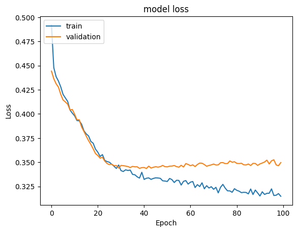

```python
#Plot Train Loss vs Validation Loss
plt.plot(history_2.history['loss'])
plt.plot(history_2.history['val_loss'])
plt.title('model loss')
plt.ylabel('Loss')
plt.xlabel('Epoch')
plt.legend(['train', 'validation'], loc='upper left')
plt.show()
```

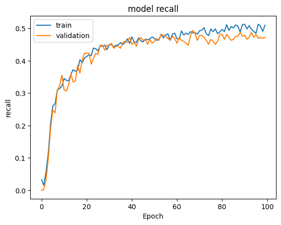

```python
# Plot Train recall vs Validation recall
plt.plot(history_2.history['recall'])
plt.plot(history_2.history['val_recall'])
plt.title('model recall')
plt.ylabel('recall')
plt.xlabel('Epoch')
plt.legend(['train', 'validation'], loc='upper left')
plt.show()
```

```python
# Predict the results using best as a threshold
y_train_pred = model_2.predict(X_train)
y_train_pred = (y_train_pred > 0.5)
y_train_pred
```

```
200/200 ━━━━━━━━━━━━━━━━━━━━ 0s 1ms/step
```

```
array([[False],
       [False],
       [False],
       ...,
       [False],
       [ True],
       [False]])
```

```python
# Predict the results using 0.5 as the threshold
y_val_pred = model_2.predict(X_val)
y_val_pred = (y_val_pred > 0.5)
y_val_pred
```

```
50/50 ━━━━━━━━━━━━━━━━━━━━ 0s 1ms/step
```

```
array([[False],
       [False],
       [False],
       ...,
       [False],
       [False],
       [False]])
```

```python
# Establish model name
model_name = "NN with Adam & Dropout"

train_metric_df.loc[model_name] = recall_score(y_train,y_train_pred)
valid_metric_df.loc[model_name] = recall_score(y_val,y_val_pred)
```

**Classification report**

```python
# Show train classification report
cr=classification_report(y_train,y_train_pred)
print(cr)
```

```
              precision    recall  f1-score   support

           0       0.89      0.97      0.93      5096
           1       0.82      0.55      0.66      1304

    accuracy                           0.89      6400
   macro avg       0.86      0.76      0.80      6400
weighted avg       0.88      0.89      0.88      6400
```

```python
# Show validation classification report
cr = classification_report(y_val,y_val_pred)
print(cr)
```

```
              precision    recall  f1-score   support

           0       0.88      0.96      0.92      1274
           1       0.76      0.47      0.58       326

    accuracy                           0.86      1600
   macro avg       0.82      0.72      0.75      1600
weighted avg       0.85      0.86      0.85      1600
```

**Confusion matrix**

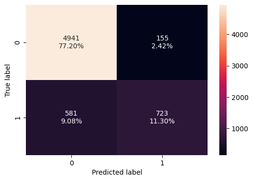

```python
# Show train the confusion matrix
make_confusion_matrix(y_train, y_train_pred)
```

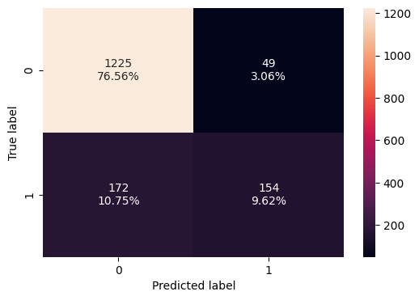

```python
# Show validation the confusion matrix
make_confusion_matrix(y_val,y_val_pred)
```

### Neural Network with Balanced Data (by applying SMOTE) and SGD Optimizer

```python
# Applying SMOTE to train data
sm  = SMOTE(random_state=42)
X_train_smote, y_train_smote= sm.fit_resample(X_train,y_train)
print('After UpSampling, the shape of train_X: {}'.format(X_train_smote.shape))
print('After UpSampling, the shape of train_y: {} \n'.format(y_train_smote.shape))
```

```
After UpSampling, the shape of train_X: (10192, 11)
After UpSampling, the shape of train_y: (10192,)
```

```python
# Adjusting the random number seed to receive same output each iteration
backend.clear_session()
np.random.seed(2)
random.seed(2)
tf.random.set_seed(2)
```

```python
# Initializing the model
model_3 = Sequential()
# Add a input layer
model_3.add(Dense(32,activation='relu',input_dim = X_train_smote.shape[1]))
# Add a hidden layer
model_3.add(Dense(16,activation='relu'))
# Add a hidden layer
model_3.add(Dense(8,activation='relu'))
# Add output layer with sigmoid activation function
model_3.add(Dense(1, activation = 'sigmoid'))
```

```python
# Set SGD as the optimizer & Recall as the metric
optimizer = tf.keras.optimizers.SGD(0.001)
metric = keras.metrics.Recall()
```

```python
# Compile the model with binary cross entropy as loss function and recall as the metric
model_3.compile(loss='binary_crossentropy',optimizer=optimizer,metrics=[metric])
```

```python
model_3.summary()
```

```
Model: "sequential"
```

```
┏━━━━━━━━━━━━━━━━━━━━━━━━━━━━━━━━━━━━━━┳━━━━━━━━━━━━━━━━━━━━━━━━━━━━━┳━━━━━━━━━━━━━━━━━┓
┃ Layer (type)                         ┃ Output Shape                ┃         Param # ┃
┡━━━━━━━━━━━━━━━━━━━━━━━━━━━━━━━━━━━━━━╇━━━━━━━━━━━━━━━━━━━━━━━━━━━━━╇━━━━━━━━━━━━━━━━━┩
│ dense (Dense)                        │ (None, 32)                  │             384 │
├──────────────────────────────────────┼─────────────────────────────┼─────────────────┤
│ dense_1 (Dense)                      │ (None, 16)                  │             528 │
├──────────────────────────────────────┼─────────────────────────────┼─────────────────┤
│ dense_2 (Dense)                      │ (None, 8)                   │             136 │
├──────────────────────────────────────┼─────────────────────────────┼─────────────────┤
│ dense_3 (Dense)                      │ (None, 1)                   │               9 │
└──────────────────────────────────────┴─────────────────────────────┴─────────────────┘
```

```
 Total params: 1,057 (4.13 KB)
```

```
 Trainable params: 1,057 (4.13 KB)
```

```
 Non-trainable params: 0 (0.00 B)
```

```python
# Fit the ANN
history_3 = model_3.fit(
    X_train_smote, y_train_smote,
    batch_size=64, # 64 is the batch size
    epochs=100, # 100 us the amount of epochs/iterations
    verbose=1,
    validation_data = (X_val,y_val)
)
```

```
160/160 ━━━━━━━━━━━━━━━━━━━━ 2s 9ms/step - loss: 0.7050 - recall: 0.9355 - val_loss: 0.7387 - val_recall: 0.9387
160/160 ━━━━━━━━━━━━━━━━━━━━ 1s 2ms/step - loss: 0.7029 - recall: 0.9304 - val_loss: 0.7329 - val_recall: 0.9264
160/160 ━━━━━━━━━━━━━━━━━━━━ 0s 2ms/step - loss: 0.7011 - recall: 0.9271 - val_loss: 0.7278 - val_recall: 0.9172
160/160 ━━━━━━━━━━━━━━━━━━━━ 0s 2ms/step - loss: 0.6995 - recall: 0.9237 - val_loss: 0.7232 - val_recall: 0.9172
160/160 ━━━━━━━━━━━━━━━━━━━━ 0s 2ms/step - loss: 0.6980 - recall: 0.9168 - val_loss: 0.7190 - val_recall: 0.9080
160/160 ━━━━━━━━━━━━━━━━━━━━ 0s 2ms/step - loss: 0.6967 - recall: 0.9026 - val_loss: 0.7150 - val_recall: 0.9049
160/160 ━━━━━━━━━━━━━━━━━━━━ 1s 3ms/step - loss: 0.6953 - recall: 0.8902 - val_loss: 0.7110 - val_recall: 0.8957
160/160 ━━━━━━━━━━━━━━━━━━━━ 1s 3ms/step - loss: 0.6940 - recall: 0.8713 - val_loss: 0.7068 - val_recall: 0.8712
160/160 ━━━━━━━━━━━━━━━━━━━━ 1s 3ms/step - loss: 0.6926 - recall: 0.8390 - val_loss: 0.7023 - val_recall: 0.8282
160/160 ━━━━━━━━━━━━━━━━━━━━ 1s 3ms/step - loss: 0.6909 - recall: 0.8031 - val_loss: 0.6973 - val_recall: 0.7945
160/160 ━━━━━━━━━━━━━━━━━━━━ 0s 3ms/step - loss: 0.6889 - recall: 0.7672 - val_loss: 0.6916 - val_recall: 0.7577
160/160 ━━━━━━━━━━━━━━━━━━━━ 1s 3ms/step - loss: 0.6866 - recall: 0.7315 - val_loss: 0.6857 - val_recall: 0.7239
160/160 ━━━━━━━━━━━━━━━━━━━━ 0s 2ms/step - loss: 0.6842 - recall: 0.6989 - val_loss: 0.6798 - val_recall: 0.6933
160/160 ━━━━━━━━━━━━━━━━━━━━ 1s 2ms/step - loss: 0.6818 - recall: 0.6723 - val_loss: 0.6742 - val_recall: 0.6748
160/160 ━━━━━━━━━━━━━━━━━━━━ 0s 2ms/step - loss: 0.6795 - recall: 0.6532 - val_loss: 0.6690 - val_recall: 0.6503
160/160 ━━━━━━━━━━━━━━━━━━━━ 0s 2ms/step - loss: 0.6773 - recall: 0.6417 - val_loss: 0.6643 - val_recall: 0.6442
160/160 ━━━━━━━━━━━━━━━━━━━━ 0s 2ms/step - loss: 0.6753 - recall: 0.6331 - val_loss: 0.6600 - val_recall: 0.6380
160/160 ━━━━━━━━━━━━━━━━━━━━ 1s 2ms/step - loss: 0.6733 - recall: 0.6324 - val_loss: 0.6560 - val_recall: 0.6288
160/160 ━━━━━━━━━━━━━━━━━━━━ 0s 2ms/step - loss: 0.6714 - recall: 0.6285 - val_loss: 0.6521 - val_recall: 0.6258
160/160 ━━━━━━━━━━━━━━━━━━━━ 1s 2ms/step - loss: 0.6695 - recall: 0.6258 - val_loss: 0.6485 - val_recall: 0.6227
160/160 ━━━━━━━━━━━━━━━━━━━━ 0s 2ms/step - loss: 0.6676 - recall: 0.6235 - val_loss: 0.6450 - val_recall: 0.6227
160/160 ━━━━━━━━━━━━━━━━━━━━ 0s 2ms/step - loss: 0.6657 - recall: 0.6241 - val_loss: 0.6418 - val_recall: 0.6227
160/160 ━━━━━━━━━━━━━━━━━━━━ 1s 2ms/step - loss: 0.6638 - recall: 0.6237 - val_loss: 0.6387 - val_recall: 0.6196
160/160 ━━━━━━━━━━━━━━━━━━━━ 0s 2ms/step - loss: 0.6618 - recall: 0.6219 - val_loss: 0.6356 - val_recall: 0.6196
160/160 ━━━━━━━━━━━━━━━━━━━━ 0s 2ms/step - loss: 0.6599 - recall: 0.6183 - val_loss: 0.6327 - val_recall: 0.6227
160/160 ━━━━━━━━━━━━━━━━━━━━ 0s 2ms/step - loss: 0.6580 - recall: 0.6170 - val_loss: 0.6299 - val_recall: 0.6104
160/160 ━━━━━━━━━━━━━━━━━━━━ 1s 2ms/step - loss: 0.6561 - recall: 0.6138 - val_loss: 0.6274 - val_recall: 0.6135
160/160 ━━━━━━━━━━━━━━━━━━━━ 0s 2ms/step - loss: 0.6542 - recall: 0.6126 - val_loss: 0.6251 - val_recall: 0.6135
160/160 ━━━━━━━━━━━━━━━━━━━━ 0s 2ms/step - loss: 0.6524 - recall: 0.6120 - val_loss: 0.6228 - val_recall: 0.6074
160/160 ━━━━━━━━━━━━━━━━━━━━ 0s 2ms/step - loss: 0.6505 - recall: 0.6131 - val_loss: 0.6206 - val_recall: 0.6074
160/160 ━━━━━━━━━━━━━━━━━━━━ 1s 2ms/step - loss: 0.6487 - recall: 0.6140 - val_loss: 0.6185 - val_recall: 0.6043
160/160 ━━━━━━━━━━━━━━━━━━━━ 0s 2ms/step - loss: 0.6468 - recall: 0.6175 - val_loss: 0.6165 - val_recall: 0.6043
160/160 ━━━━━━━━━━━━━━━━━━━━ 0s 2ms/step - loss: 0.6449 - recall: 0.6202 - val_loss: 0.6146 - val_recall: 0.6043
160/160 ━━━━━━━━━━━━━━━━━━━━ 1s 2ms/step - loss: 0.6430 - recall: 0.6230 - val_loss: 0.6128 - val_recall: 0.6043
160/160 ━━━━━━━━━━━━━━━━━━━━ 1s 2ms/step - loss: 0.6412 - recall: 0.6266 - val_loss: 0.6110 - val_recall: 0.5951
160/160 ━━━━━━━━━━━━━━━━━━━━ 0s 3ms/step - loss: 0.6393 - recall: 0.6298 - val_loss: 0.6094 - val_recall: 0.5951
160/160 ━━━━━━━━━━━━━━━━━━━━ 1s 3ms/step - loss: 0.6374 - recall: 0.6331 - val_loss: 0.6079 - val_recall: 0.5951
160/160 ━━━━━━━━━━━━━━━━━━━━ 0s 3ms/step - loss: 0.6354 - recall: 0.6373 - val_loss: 0.6065 - val_recall: 0.6043
160/160 ━━━━━━━━━━━━━━━━━━━━ 1s 3ms/step - loss: 0.6335 - recall: 0.6398 - val_loss: 0.6051 - val_recall: 0.6043
160/160 ━━━━━━━━━━━━━━━━━━━━ 0s 3ms/step - loss: 0.6316 - recall: 0.6426 - val_loss: 0.6038 - val_recall: 0.6012
```

[output cut: 45 more lines]

```
160/160 ━━━━━━━━━━━━━━━━━━━━ 0s 2ms/step - loss: 0.5689 - recall: 0.7165 - val_loss: 0.5684 - val_recall: 0.6902
160/160 ━━━━━━━━━━━━━━━━━━━━ 0s 2ms/step - loss: 0.5684 - recall: 0.7162 - val_loss: 0.5682 - val_recall: 0.6902
160/160 ━━━━━━━━━━━━━━━━━━━━ 0s 2ms/step - loss: 0.5679 - recall: 0.7155 - val_loss: 0.5680 - val_recall: 0.6902
160/160 ━━━━━━━━━━━━━━━━━━━━ 0s 2ms/step - loss: 0.5674 - recall: 0.7149 - val_loss: 0.5678 - val_recall: 0.6933
160/160 ━━━━━━━━━━━━━━━━━━━━ 0s 2ms/step - loss: 0.5669 - recall: 0.7156 - val_loss: 0.5676 - val_recall: 0.6933
160/160 ━━━━━━━━━━━━━━━━━━━━ 1s 2ms/step - loss: 0.5665 - recall: 0.7160 - val_loss: 0.5673 - val_recall: 0.6963
160/160 ━━━━━━━━━━━━━━━━━━━━ 1s 2ms/step - loss: 0.5660 - recall: 0.7168 - val_loss: 0.5672 - val_recall: 0.6933
160/160 ━━━━━━━━━━━━━━━━━━━━ 1s 2ms/step - loss: 0.5656 - recall: 0.7173 - val_loss: 0.5669 - val_recall: 0.6933
160/160 ━━━━━━━━━━━━━━━━━━━━ 0s 3ms/step - loss: 0.5652 - recall: 0.7168 - val_loss: 0.5668 - val_recall: 0.6933
160/160 ━━━━━━━━━━━━━━━━━━━━ 1s 3ms/step - loss: 0.5648 - recall: 0.7162 - val_loss: 0.5666 - val_recall: 0.6963
160/160 ━━━━━━━━━━━━━━━━━━━━ 0s 3ms/step - loss: 0.5644 - recall: 0.7173 - val_loss: 0.5664 - val_recall: 0.6963
160/160 ━━━━━━━━━━━━━━━━━━━━ 0s 3ms/step - loss: 0.5641 - recall: 0.7170 - val_loss: 0.5662 - val_recall: 0.6963
160/160 ━━━━━━━━━━━━━━━━━━━━ 0s 3ms/step - loss: 0.5637 - recall: 0.7176 - val_loss: 0.5660 - val_recall: 0.6963
160/160 ━━━━━━━━━━━━━━━━━━━━ 1s 3ms/step - loss: 0.5634 - recall: 0.7189 - val_loss: 0.5658 - val_recall: 0.6963
160/160 ━━━━━━━━━━━━━━━━━━━━ 1s 3ms/step - loss: 0.5630 - recall: 0.7188 - val_loss: 0.5656 - val_recall: 0.6933
```

**Loss function**

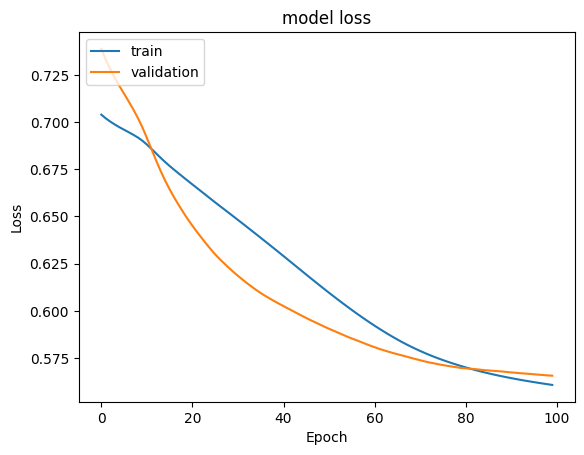

```python
# Plot Train Loss vs Validation Loss
plt.plot(history_3.history['loss'])
plt.plot(history_3.history['val_loss'])
plt.title('model loss')
plt.ylabel('Loss')
plt.xlabel('Epoch')
plt.legend(['train', 'validation'], loc='upper left')
plt.show()
```

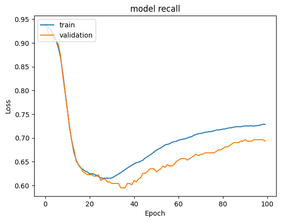

```python
# Plot Train recall vs Validation recall
plt.plot(history_3.history['recall'])
plt.plot(history_3.history['val_recall'])
plt.title('model recall')
plt.ylabel('Loss')
plt.xlabel('Epoch')
plt.legend(['train', 'validation'], loc='upper left')
plt.show()
```

```python
# Predict the result using 0.5 as the threshold on SMOTE train set
y_train_pred = model_3.predict(X_train_smote)
y_train_pred = (y_train_pred > 0.5)
y_train_pred
```

```
319/319 ━━━━━━━━━━━━━━━━━━━━ 1s 2ms/step
```

```
array([[ True],
       [False],
       [False],
       ...,
       [ True],
       [ True],
       [ True]])
```

```python
# Predict the threshold by using 0.5 as the threshold on validation set
y_val_pred = model_3.predict(X_val)
y_val_pred = (y_val_pred > 0.5)
y_val_pred
```

```
50/50 ━━━━━━━━━━━━━━━━━━━━ 0s 1ms/step
```

```
array([[ True],
       [False],
       [False],
       ...,
       [False],
       [ True],
       [ True]])
```

```python
# Establish model name
model_name = "NN with SMOTE & SGD"
train_metric_df.loc[model_name] = recall_score(y_train_smote,y_train_pred)
valid_metric_df.loc[model_name] = recall_score(y_val,y_val_pred)
```

**Classification report**

```python
# Show SMOTE train classification report
cr=classification_report(y_train_smote,y_train_pred)
print(cr)
```

```
              precision    recall  f1-score   support

           0       0.73      0.73      0.73      5096
           1       0.73      0.73      0.73      5096

    accuracy                           0.73     10192
   macro avg       0.73      0.73      0.73     10192
weighted avg       0.73      0.73      0.73     10192
```

```python
# Show validation classification report
cr=classification_report(y_val,y_val_pred)
print(cr)
```

```
              precision    recall  f1-score   support

           0       0.90      0.72      0.80      1274
           1       0.39      0.69      0.50       326

    accuracy                           0.72      1600
   macro avg       0.65      0.71      0.65      1600
weighted avg       0.80      0.72      0.74      1600
```

**Confusion matrix**

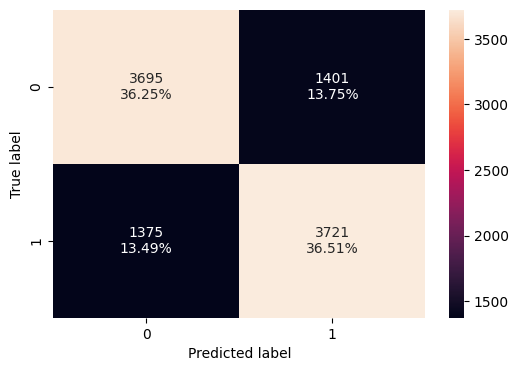

```python
# Show the SMOTE train confusion matrix
make_confusion_matrix(y_train_smote, y_train_pred)
```

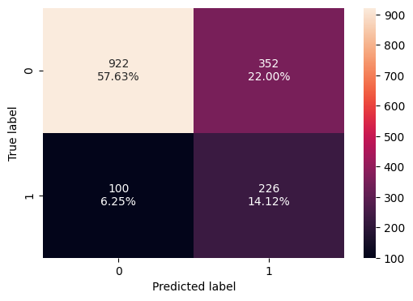

```python
# Show the validation confusion matrix
make_confusion_matrix(y_val,y_val_pred)
```

### Neural Network with Balanced Data (by applying SMOTE) and Adam Optimizer

```python
# Adjusting the random number seed to receive same output each iteration
backend.clear_session()
np.random.seed(2)
random.seed(2)
tf.random.set_seed(2)
```

```python
# Initializing the model
model_4 = Sequential()
# Add input layer
model_4.add(Dense(32,activation='relu',input_dim = X_train_smote.shape[1]))
# Add hidden layer
model_4.add(Dense(16,activation='relu'))
# Add a hidden layer
model_4.add(Dense(8,activation='relu'))
# Add output layer with SIGMOID activation function.
model_4.add(Dense(1, activation = 'sigmoid'))
```

```python
model_4.summary()
```

```
Model: "sequential"
```

```
┏━━━━━━━━━━━━━━━━━━━━━━━━━━━━━━━━━━━━━━┳━━━━━━━━━━━━━━━━━━━━━━━━━━━━━┳━━━━━━━━━━━━━━━━━┓
┃ Layer (type)                         ┃ Output Shape                ┃         Param # ┃
┡━━━━━━━━━━━━━━━━━━━━━━━━━━━━━━━━━━━━━━╇━━━━━━━━━━━━━━━━━━━━━━━━━━━━━╇━━━━━━━━━━━━━━━━━┩
│ dense (Dense)                        │ (None, 32)                  │             384 │
├──────────────────────────────────────┼─────────────────────────────┼─────────────────┤
│ dense_1 (Dense)                      │ (None, 16)                  │             528 │
├──────────────────────────────────────┼─────────────────────────────┼─────────────────┤
│ dense_2 (Dense)                      │ (None, 8)                   │             136 │
├──────────────────────────────────────┼─────────────────────────────┼─────────────────┤
│ dense_3 (Dense)                      │ (None, 1)                   │               9 │
└──────────────────────────────────────┴─────────────────────────────┴─────────────────┘
```

```
 Total params: 1,057 (4.13 KB)
```

```
 Trainable params: 1,057 (4.13 KB)
```

```
 Non-trainable params: 0 (0.00 B)
```

```python
# Set ADAM as the optimizer and Recall as the metric
optimizer = tf.keras.optimizers.Adam()
metric = keras.metrics.Recall()
```

```python
# Compile the model with binary cross entropy as loss function and recall as the metric
model_4.compile(loss='binary_crossentropy',optimizer=optimizer,metrics=[metric])
```

```python
model_4.summary()
```

```
Model: "sequential"
```

```
┏━━━━━━━━━━━━━━━━━━━━━━━━━━━━━━━━━━━━━━┳━━━━━━━━━━━━━━━━━━━━━━━━━━━━━┳━━━━━━━━━━━━━━━━━┓
┃ Layer (type)                         ┃ Output Shape                ┃         Param # ┃
┡━━━━━━━━━━━━━━━━━━━━━━━━━━━━━━━━━━━━━━╇━━━━━━━━━━━━━━━━━━━━━━━━━━━━━╇━━━━━━━━━━━━━━━━━┩
│ dense (Dense)                        │ (None, 32)                  │             384 │
├──────────────────────────────────────┼─────────────────────────────┼─────────────────┤
│ dense_1 (Dense)                      │ (None, 16)                  │             528 │
├──────────────────────────────────────┼─────────────────────────────┼─────────────────┤
│ dense_2 (Dense)                      │ (None, 8)                   │             136 │
├──────────────────────────────────────┼─────────────────────────────┼─────────────────┤
│ dense_3 (Dense)                      │ (None, 1)                   │               9 │
└──────────────────────────────────────┴─────────────────────────────┴─────────────────┘
```

```
 Total params: 1,057 (4.13 KB)
```

```
 Trainable params: 1,057 (4.13 KB)
```

```
 Non-trainable params: 0 (0.00 B)
```

```python
# Fit the ANN

history_4 = model_4.fit(
    X_train_smote,y_train_smote,
    batch_size=64, # 64 is the batch size
    epochs=100,  # 100 is the number of epochs/iterations
    verbose=1,
    validation_data = (X_val,y_val)
)
```

```
160/160 ━━━━━━━━━━━━━━━━━━━━ 3s 9ms/step - loss: 0.6589 - recall: 0.7627 - val_loss: 0.5729 - val_recall: 0.6994
160/160 ━━━━━━━━━━━━━━━━━━━━ 0s 2ms/step - loss: 0.5597 - recall: 0.7268 - val_loss: 0.5638 - val_recall: 0.7117
160/160 ━━━━━━━━━━━━━━━━━━━━ 1s 2ms/step - loss: 0.5433 - recall: 0.7451 - val_loss: 0.5574 - val_recall: 0.7086
160/160 ━━━━━━━━━━━━━━━━━━━━ 1s 2ms/step - loss: 0.5246 - recall: 0.7556 - val_loss: 0.5455 - val_recall: 0.7362
160/160 ━━━━━━━━━━━━━━━━━━━━ 0s 2ms/step - loss: 0.4987 - recall: 0.7747 - val_loss: 0.5302 - val_recall: 0.7393
160/160 ━━━━━━━━━━━━━━━━━━━━ 1s 2ms/step - loss: 0.4746 - recall: 0.7871 - val_loss: 0.5185 - val_recall: 0.7546
160/160 ━━━━━━━━━━━━━━━━━━━━ 0s 2ms/step - loss: 0.4556 - recall: 0.7918 - val_loss: 0.5091 - val_recall: 0.7577
160/160 ━━━━━━━━━━━━━━━━━━━━ 0s 2ms/step - loss: 0.4418 - recall: 0.7991 - val_loss: 0.5083 - val_recall: 0.7607
160/160 ━━━━━━━━━━━━━━━━━━━━ 1s 3ms/step - loss: 0.4326 - recall: 0.7972 - val_loss: 0.5069 - val_recall: 0.7577
160/160 ━━━━━━━━━━━━━━━━━━━━ 1s 3ms/step - loss: 0.4251 - recall: 0.8006 - val_loss: 0.5078 - val_recall: 0.7546
160/160 ━━━━━━━━━━━━━━━━━━━━ 1s 3ms/step - loss: 0.4191 - recall: 0.8009 - val_loss: 0.5076 - val_recall: 0.7577
160/160 ━━━━━━━━━━━━━━━━━━━━ 1s 3ms/step - loss: 0.4138 - recall: 0.8057 - val_loss: 0.5068 - val_recall: 0.7669
160/160 ━━━━━━━━━━━━━━━━━━━━ 1s 3ms/step - loss: 0.4097 - recall: 0.8077 - val_loss: 0.5070 - val_recall: 0.7699
160/160 ━━━━━━━━━━━━━━━━━━━━ 0s 2ms/step - loss: 0.4063 - recall: 0.8114 - val_loss: 0.5083 - val_recall: 0.7699
160/160 ━━━━━━━━━━━━━━━━━━━━ 0s 2ms/step - loss: 0.4033 - recall: 0.8144 - val_loss: 0.5083 - val_recall: 0.7638
160/160 ━━━━━━━━━━━━━━━━━━━━ 0s 2ms/step - loss: 0.4008 - recall: 0.8152 - val_loss: 0.5088 - val_recall: 0.7546
160/160 ━━━━━━━━━━━━━━━━━━━━ 0s 2ms/step - loss: 0.3984 - recall: 0.8137 - val_loss: 0.5117 - val_recall: 0.7669
160/160 ━━━━━━━━━━━━━━━━━━━━ 0s 2ms/step - loss: 0.3964 - recall: 0.8140 - val_loss: 0.5125 - val_recall: 0.7638
160/160 ━━━━━━━━━━━━━━━━━━━━ 1s 2ms/step - loss: 0.3946 - recall: 0.8162 - val_loss: 0.5128 - val_recall: 0.7607
160/160 ━━━━━━━━━━━━━━━━━━━━ 0s 2ms/step - loss: 0.3925 - recall: 0.8171 - val_loss: 0.5130 - val_recall: 0.7577
160/160 ━━━━━━━━━━━━━━━━━━━━ 0s 2ms/step - loss: 0.3908 - recall: 0.8164 - val_loss: 0.5137 - val_recall: 0.7485
160/160 ━━━━━━━━━━━━━━━━━━━━ 0s 2ms/step - loss: 0.3891 - recall: 0.8191 - val_loss: 0.5145 - val_recall: 0.7515
160/160 ━━━━━━━━━━━━━━━━━━━━ 0s 2ms/step - loss: 0.3876 - recall: 0.8239 - val_loss: 0.5146 - val_recall: 0.7423
160/160 ━━━━━━━━━━━━━━━━━━━━ 0s 2ms/step - loss: 0.3861 - recall: 0.8244 - val_loss: 0.5144 - val_recall: 0.7362
160/160 ━━━━━━━━━━━━━━━━━━━━ 0s 2ms/step - loss: 0.3847 - recall: 0.8270 - val_loss: 0.5139 - val_recall: 0.7362
160/160 ━━━━━━━━━━━━━━━━━━━━ 1s 2ms/step - loss: 0.3834 - recall: 0.8286 - val_loss: 0.5152 - val_recall: 0.7393
160/160 ━━━━━━━━━━━━━━━━━━━━ 0s 2ms/step - loss: 0.3821 - recall: 0.8295 - val_loss: 0.5131 - val_recall: 0.7362
160/160 ━━━━━━━━━━━━━━━━━━━━ 1s 2ms/step - loss: 0.3807 - recall: 0.8314 - val_loss: 0.5149 - val_recall: 0.7423
160/160 ━━━━━━━━━━━━━━━━━━━━ 0s 2ms/step - loss: 0.3796 - recall: 0.8315 - val_loss: 0.5163 - val_recall: 0.7393
160/160 ━━━━━━━━━━━━━━━━━━━━ 1s 2ms/step - loss: 0.3785 - recall: 0.8316 - val_loss: 0.5148 - val_recall: 0.7362
160/160 ━━━━━━━━━━━━━━━━━━━━ 0s 2ms/step - loss: 0.3771 - recall: 0.8325 - val_loss: 0.5138 - val_recall: 0.7270
160/160 ━━━━━━━━━━━━━━━━━━━━ 0s 2ms/step - loss: 0.3759 - recall: 0.8332 - val_loss: 0.5147 - val_recall: 0.7301
160/160 ━━━━━━━━━━━━━━━━━━━━ 1s 2ms/step - loss: 0.3745 - recall: 0.8327 - val_loss: 0.5146 - val_recall: 0.7270
160/160 ━━━━━━━━━━━━━━━━━━━━ 1s 2ms/step - loss: 0.3733 - recall: 0.8336 - val_loss: 0.5149 - val_recall: 0.7270
160/160 ━━━━━━━━━━━━━━━━━━━━ 1s 2ms/step - loss: 0.3723 - recall: 0.8352 - val_loss: 0.5156 - val_recall: 0.7239
160/160 ━━━━━━━━━━━━━━━━━━━━ 0s 3ms/step - loss: 0.3714 - recall: 0.8348 - val_loss: 0.5156 - val_recall: 0.7239
160/160 ━━━━━━━━━━━━━━━━━━━━ 1s 3ms/step - loss: 0.3702 - recall: 0.8358 - val_loss: 0.5149 - val_recall: 0.7239
160/160 ━━━━━━━━━━━━━━━━━━━━ 1s 3ms/step - loss: 0.3689 - recall: 0.8369 - val_loss: 0.5178 - val_recall: 0.7270
160/160 ━━━━━━━━━━━━━━━━━━━━ 1s 3ms/step - loss: 0.3678 - recall: 0.8375 - val_loss: 0.5172 - val_recall: 0.7270
160/160 ━━━━━━━━━━━━━━━━━━━━ 1s 3ms/step - loss: 0.3663 - recall: 0.8369 - val_loss: 0.5181 - val_recall: 0.7270
```

[output cut: 45 more lines]

```
160/160 ━━━━━━━━━━━━━━━━━━━━ 0s 2ms/step - loss: 0.3299 - recall: 0.8599 - val_loss: 0.5426 - val_recall: 0.7362
160/160 ━━━━━━━━━━━━━━━━━━━━ 1s 3ms/step - loss: 0.3293 - recall: 0.8596 - val_loss: 0.5436 - val_recall: 0.7331
160/160 ━━━━━━━━━━━━━━━━━━━━ 1s 3ms/step - loss: 0.3287 - recall: 0.8587 - val_loss: 0.5443 - val_recall: 0.7331
160/160 ━━━━━━━━━━━━━━━━━━━━ 1s 3ms/step - loss: 0.3284 - recall: 0.8600 - val_loss: 0.5449 - val_recall: 0.7362
160/160 ━━━━━━━━━━━━━━━━━━━━ 1s 3ms/step - loss: 0.3279 - recall: 0.8601 - val_loss: 0.5445 - val_recall: 0.7301
160/160 ━━━━━━━━━━━━━━━━━━━━ 1s 3ms/step - loss: 0.3274 - recall: 0.8610 - val_loss: 0.5447 - val_recall: 0.7331
160/160 ━━━━━━━━━━━━━━━━━━━━ 1s 3ms/step - loss: 0.3270 - recall: 0.8623 - val_loss: 0.5440 - val_recall: 0.7331
160/160 ━━━━━━━━━━━━━━━━━━━━ 0s 2ms/step - loss: 0.3264 - recall: 0.8620 - val_loss: 0.5450 - val_recall: 0.7301
160/160 ━━━━━━━━━━━━━━━━━━━━ 1s 2ms/step - loss: 0.3261 - recall: 0.8622 - val_loss: 0.5436 - val_recall: 0.7331
160/160 ━━━━━━━━━━━━━━━━━━━━ 0s 2ms/step - loss: 0.3256 - recall: 0.8624 - val_loss: 0.5436 - val_recall: 0.7331
160/160 ━━━━━━━━━━━━━━━━━━━━ 1s 2ms/step - loss: 0.3251 - recall: 0.8628 - val_loss: 0.5453 - val_recall: 0.7301
160/160 ━━━━━━━━━━━━━━━━━━━━ 0s 2ms/step - loss: 0.3247 - recall: 0.8634 - val_loss: 0.5454 - val_recall: 0.7331
160/160 ━━━━━━━━━━━━━━━━━━━━ 1s 2ms/step - loss: 0.3241 - recall: 0.8610 - val_loss: 0.5457 - val_recall: 0.7331
160/160 ━━━━━━━━━━━━━━━━━━━━ 0s 2ms/step - loss: 0.3235 - recall: 0.8629 - val_loss: 0.5473 - val_recall: 0.7301
160/160 ━━━━━━━━━━━━━━━━━━━━ 1s 2ms/step - loss: 0.3231 - recall: 0.8635 - val_loss: 0.5467 - val_recall: 0.7270
```

**Loss function**

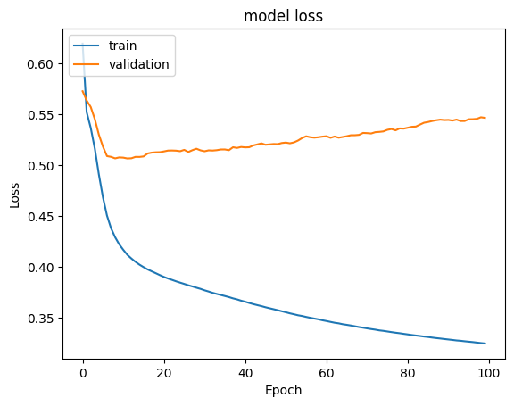

```python
# Plot Train Loss vs Validation Loss
plt.plot(history_4.history['loss'])
plt.plot(history_4.history['val_loss'])
plt.title('model loss')
plt.ylabel('Loss')
plt.xlabel('Epoch')
plt.legend(['train', 'validation'], loc='upper left')
plt.show()
```

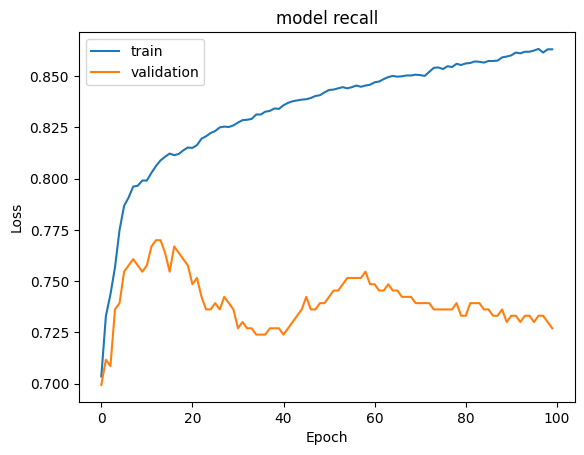

```python
# Plot Train recall vs Validation recall
plt.plot(history_4.history['recall'])
plt.plot(history_4.history['val_recall'])
plt.title('model recall')
plt.ylabel('Loss')
plt.xlabel('Epoch')
plt.legend(['train', 'validation'], loc='upper left')
plt.show()
```

```python
# Predict the results by using 0.5 as the threshold
y_train_pred = model_4.predict(X_train_smote)
y_train_pred = (y_train_pred > 0.5)
y_train_pred
```

```
319/319 ━━━━━━━━━━━━━━━━━━━━ 1s 2ms/step
```

```
array([[ True],
       [False],
       [False],
       ...,
       [ True],
       [ True],
       [ True]])
```

```python
# Predict the results using 0.5 as the threshold
y_val_pred = model_4.predict(X_val)
y_val_pred = (y_val_pred > 0.5)
y_val_pred
```

```
50/50 ━━━━━━━━━━━━━━━━━━━━ 0s 1ms/step
```

```
array([[ True],
       [False],
       [False],
       ...,
       [False],
       [ True],
       [ True]])
```

```python
# Establish model name
model_name = "NN with SMOTE & Adam"
train_metric_df.loc[model_name] = recall_score(y_train_smote,y_train_pred)
valid_metric_df.loc[model_name] = recall_score(y_val,y_val_pred)
```

**Classification report**

```python
# Show SMOTE train classification report
cr=classification_report(y_train_smote,y_train_pred)
print(cr)
```

```
              precision    recall  f1-score   support

           0       0.90      0.82      0.86      5096
           1       0.84      0.91      0.87      5096

    accuracy                           0.86     10192
   macro avg       0.87      0.86      0.86     10192
weighted avg       0.87      0.86      0.86     10192
```

```python
# Show validation classification report
cr=classification_report(y_val,y_val_pred)
print(cr)
```

```
              precision    recall  f1-score   support

           0       0.92      0.78      0.84      1274
           1       0.46      0.73      0.56       326

    accuracy                           0.77      1600
   macro avg       0.69      0.75      0.70      1600
weighted avg       0.82      0.77      0.79      1600
```

**Confusion matrix**

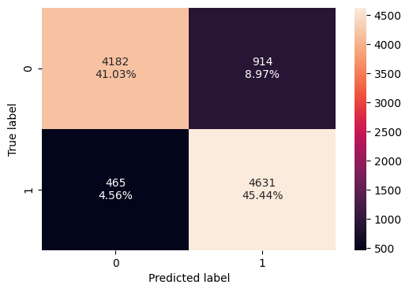

```python
# Show SMOTE train confusion matrix
make_confusion_matrix(y_train_smote, y_train_pred)
```

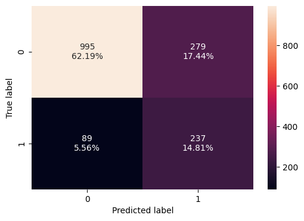

```python
# Show validation confusion matrix
make_confusion_matrix(y_val,y_val_pred)
```

### Neural Network with Balanced Data (by applying SMOTE), Adam Optimizer, and Dropout

```python
# Adjusting the random number seed to receive same output each iteration
backend.clear_session()
np.random.seed(2)
random.seed(2)
tf.random.set_seed(2)
```

```python
# Initializing the model
model_5 = Sequential()
# Add input layer
model_5.add(Dense(32,activation='relu',input_dim = X_train_smote.shape[1]))
# Add dropout at 0.3
model_5.add(Dropout(0.3))
# Add hidden layer
model_5.add(Dense(16,activation='relu'))
# Add dropout rate 0.1
model_5.add(Dropout(0.1))
# Add hidden layer
model_5.add(Dense(8,activation='relu'))
# Add output layer
model_5.add(Dense(1, activation = 'sigmoid'))
```

```python
# Set ADAM as the optimizer & Recall as the metric
optimizer = tf.keras.optimizers.Adam()
metric = keras.metrics.Recall()
```

```python
# Compile the model with binary cross entropy as loss function and recall as the metric
model_5.compile(loss='binary_crossentropy',optimizer=optimizer,metrics=[metric])
```

```python
model_5.summary()
```

```
Model: "sequential"
```

```
┏━━━━━━━━━━━━━━━━━━━━━━━━━━━━━━━━━━━━━━┳━━━━━━━━━━━━━━━━━━━━━━━━━━━━━┳━━━━━━━━━━━━━━━━━┓
┃ Layer (type)                         ┃ Output Shape                ┃         Param # ┃
┡━━━━━━━━━━━━━━━━━━━━━━━━━━━━━━━━━━━━━━╇━━━━━━━━━━━━━━━━━━━━━━━━━━━━━╇━━━━━━━━━━━━━━━━━┩
│ dense (Dense)                        │ (None, 32)                  │             384 │
├──────────────────────────────────────┼─────────────────────────────┼─────────────────┤
│ dropout (Dropout)                    │ (None, 32)                  │               0 │
├──────────────────────────────────────┼─────────────────────────────┼─────────────────┤
│ dense_1 (Dense)                      │ (None, 16)                  │             528 │
├──────────────────────────────────────┼─────────────────────────────┼─────────────────┤
│ dropout_1 (Dropout)                  │ (None, 16)                  │               0 │
├──────────────────────────────────────┼─────────────────────────────┼─────────────────┤
│ dense_2 (Dense)                      │ (None, 8)                   │             136 │
├──────────────────────────────────────┼─────────────────────────────┼─────────────────┤
│ dense_3 (Dense)                      │ (None, 1)                   │               9 │
└──────────────────────────────────────┴─────────────────────────────┴─────────────────┘
```

```
 Total params: 1,057 (4.13 KB)
```

```
 Trainable params: 1,057 (4.13 KB)
```

```
 Non-trainable params: 0 (0.00 B)
```

```python
history_5 = model_5.fit(
    X_train_smote,y_train_smote,
    batch_size=64, # 64 is the batch size
    epochs=100, # 100 is the number of epochs/iterations
    verbose=1,
    validation_data = (X_val,y_val))
```

```
160/160 ━━━━━━━━━━━━━━━━━━━━ 6s 22ms/step - loss: 0.6567 - recall: 0.5697 - val_loss: 0.5667 - val_recall: 0.6503
160/160 ━━━━━━━━━━━━━━━━━━━━ 0s 2ms/step - loss: 0.5864 - recall: 0.7059 - val_loss: 0.5582 - val_recall: 0.6656
160/160 ━━━━━━━━━━━━━━━━━━━━ 1s 2ms/step - loss: 0.5727 - recall: 0.7098 - val_loss: 0.5549 - val_recall: 0.6840
160/160 ━━━━━━━━━━━━━━━━━━━━ 1s 2ms/step - loss: 0.5650 - recall: 0.7177 - val_loss: 0.5376 - val_recall: 0.6718
160/160 ━━━━━━━━━━━━━━━━━━━━ 0s 2ms/step - loss: 0.5490 - recall: 0.7255 - val_loss: 0.5410 - val_recall: 0.6779
160/160 ━━━━━━━━━━━━━━━━━━━━ 1s 2ms/step - loss: 0.5404 - recall: 0.7367 - val_loss: 0.5307 - val_recall: 0.6656
160/160 ━━━━━━━━━━━━━━━━━━━━ 1s 2ms/step - loss: 0.5343 - recall: 0.7324 - val_loss: 0.5304 - val_recall: 0.6718
160/160 ━━━━━━━━━━━━━━━━━━━━ 1s 2ms/step - loss: 0.5257 - recall: 0.7324 - val_loss: 0.5255 - val_recall: 0.6626
160/160 ━━━━━━━━━━━━━━━━━━━━ 1s 2ms/step - loss: 0.5144 - recall: 0.7439 - val_loss: 0.5235 - val_recall: 0.6718
160/160 ━━━━━━━━━━━━━━━━━━━━ 0s 2ms/step - loss: 0.5113 - recall: 0.7421 - val_loss: 0.5204 - val_recall: 0.6902
160/160 ━━━━━━━━━━━━━━━━━━━━ 1s 2ms/step - loss: 0.5051 - recall: 0.7403 - val_loss: 0.5166 - val_recall: 0.6871
160/160 ━━━━━━━━━━━━━━━━━━━━ 1s 2ms/step - loss: 0.4956 - recall: 0.7576 - val_loss: 0.5145 - val_recall: 0.7055
160/160 ━━━━━━━━━━━━━━━━━━━━ 0s 2ms/step - loss: 0.4975 - recall: 0.7597 - val_loss: 0.5133 - val_recall: 0.7025
160/160 ━━━━━━━━━━━━━━━━━━━━ 1s 2ms/step - loss: 0.4883 - recall: 0.7605 - val_loss: 0.5042 - val_recall: 0.7025
160/160 ━━━━━━━━━━━━━━━━━━━━ 1s 2ms/step - loss: 0.4824 - recall: 0.7518 - val_loss: 0.5040 - val_recall: 0.7209
160/160 ━━━━━━━━━━━━━━━━━━━━ 1s 2ms/step - loss: 0.4776 - recall: 0.7645 - val_loss: 0.4995 - val_recall: 0.7270
160/160 ━━━━━━━━━━━━━━━━━━━━ 1s 2ms/step - loss: 0.4717 - recall: 0.7591 - val_loss: 0.4918 - val_recall: 0.7117
160/160 ━━━━━━━━━━━━━━━━━━━━ 0s 2ms/step - loss: 0.4767 - recall: 0.7546 - val_loss: 0.4882 - val_recall: 0.7178
160/160 ━━━━━━━━━━━━━━━━━━━━ 1s 2ms/step - loss: 0.4697 - recall: 0.7688 - val_loss: 0.4844 - val_recall: 0.7025
160/160 ━━━━━━━━━━━━━━━━━━━━ 0s 3ms/step - loss: 0.4663 - recall: 0.7733 - val_loss: 0.4834 - val_recall: 0.7147
160/160 ━━━━━━━━━━━━━━━━━━━━ 1s 3ms/step - loss: 0.4676 - recall: 0.7652 - val_loss: 0.4780 - val_recall: 0.7086
160/160 ━━━━━━━━━━━━━━━━━━━━ 1s 3ms/step - loss: 0.4596 - recall: 0.7820 - val_loss: 0.4866 - val_recall: 0.7393
160/160 ━━━━━━━━━━━━━━━━━━━━ 1s 3ms/step - loss: 0.4591 - recall: 0.7797 - val_loss: 0.4719 - val_recall: 0.7117
160/160 ━━━━━━━━━━━━━━━━━━━━ 1s 3ms/step - loss: 0.4562 - recall: 0.7690 - val_loss: 0.4686 - val_recall: 0.7178
160/160 ━━━━━━━━━━━━━━━━━━━━ 1s 4ms/step - loss: 0.4495 - recall: 0.7813 - val_loss: 0.4795 - val_recall: 0.7362
160/160 ━━━━━━━━━━━━━━━━━━━━ 0s 2ms/step - loss: 0.4498 - recall: 0.7855 - val_loss: 0.4700 - val_recall: 0.7270
160/160 ━━━━━━━━━━━━━━━━━━━━ 0s 2ms/step - loss: 0.4538 - recall: 0.7766 - val_loss: 0.4641 - val_recall: 0.7454
160/160 ━━━━━━━━━━━━━━━━━━━━ 1s 2ms/step - loss: 0.4448 - recall: 0.7907 - val_loss: 0.4641 - val_recall: 0.7454
160/160 ━━━━━━━━━━━━━━━━━━━━ 0s 2ms/step - loss: 0.4385 - recall: 0.7979 - val_loss: 0.4643 - val_recall: 0.7485
160/160 ━━━━━━━━━━━━━━━━━━━━ 0s 2ms/step - loss: 0.4416 - recall: 0.7905 - val_loss: 0.4542 - val_recall: 0.7362
160/160 ━━━━━━━━━━━━━━━━━━━━ 1s 2ms/step - loss: 0.4460 - recall: 0.7761 - val_loss: 0.4578 - val_recall: 0.7454
160/160 ━━━━━━━━━━━━━━━━━━━━ 0s 2ms/step - loss: 0.4384 - recall: 0.7898 - val_loss: 0.4597 - val_recall: 0.7485
160/160 ━━━━━━━━━━━━━━━━━━━━ 1s 2ms/step - loss: 0.4412 - recall: 0.7945 - val_loss: 0.4505 - val_recall: 0.7423
160/160 ━━━━━━━━━━━━━━━━━━━━ 1s 2ms/step - loss: 0.4354 - recall: 0.7942 - val_loss: 0.4529 - val_recall: 0.7393
160/160 ━━━━━━━━━━━━━━━━━━━━ 0s 2ms/step - loss: 0.4324 - recall: 0.8009 - val_loss: 0.4536 - val_recall: 0.7393
160/160 ━━━━━━━━━━━━━━━━━━━━ 1s 2ms/step - loss: 0.4309 - recall: 0.8040 - val_loss: 0.4548 - val_recall: 0.7454
160/160 ━━━━━━━━━━━━━━━━━━━━ 0s 2ms/step - loss: 0.4308 - recall: 0.8044 - val_loss: 0.4538 - val_recall: 0.7515
160/160 ━━━━━━━━━━━━━━━━━━━━ 0s 2ms/step - loss: 0.4318 - recall: 0.7978 - val_loss: 0.4577 - val_recall: 0.7515
160/160 ━━━━━━━━━━━━━━━━━━━━ 0s 2ms/step - loss: 0.4252 - recall: 0.8005 - val_loss: 0.4482 - val_recall: 0.7331
160/160 ━━━━━━━━━━━━━━━━━━━━ 1s 2ms/step - loss: 0.4302 - recall: 0.8020 - val_loss: 0.4515 - val_recall: 0.7423
```

[output cut: 45 more lines]

```
160/160 ━━━━━━━━━━━━━━━━━━━━ 1s 2ms/step - loss: 0.4006 - recall: 0.8129 - val_loss: 0.4575 - val_recall: 0.7669
160/160 ━━━━━━━━━━━━━━━━━━━━ 1s 2ms/step - loss: 0.4013 - recall: 0.8222 - val_loss: 0.4559 - val_recall: 0.7607
160/160 ━━━━━━━━━━━━━━━━━━━━ 1s 2ms/step - loss: 0.4073 - recall: 0.8297 - val_loss: 0.4587 - val_recall: 0.7638
160/160 ━━━━━━━━━━━━━━━━━━━━ 0s 2ms/step - loss: 0.4035 - recall: 0.8353 - val_loss: 0.4675 - val_recall: 0.7638
160/160 ━━━━━━━━━━━━━━━━━━━━ 1s 2ms/step - loss: 0.4088 - recall: 0.8237 - val_loss: 0.4609 - val_recall: 0.7699
160/160 ━━━━━━━━━━━━━━━━━━━━ 0s 2ms/step - loss: 0.4123 - recall: 0.8171 - val_loss: 0.4489 - val_recall: 0.7515
160/160 ━━━━━━━━━━━━━━━━━━━━ 0s 2ms/step - loss: 0.4005 - recall: 0.8218 - val_loss: 0.4559 - val_recall: 0.7546
160/160 ━━━━━━━━━━━━━━━━━━━━ 1s 2ms/step - loss: 0.4046 - recall: 0.8232 - val_loss: 0.4523 - val_recall: 0.7515
160/160 ━━━━━━━━━━━━━━━━━━━━ 1s 2ms/step - loss: 0.4003 - recall: 0.8282 - val_loss: 0.4622 - val_recall: 0.7761
160/160 ━━━━━━━━━━━━━━━━━━━━ 1s 2ms/step - loss: 0.4036 - recall: 0.8302 - val_loss: 0.4639 - val_recall: 0.7638
160/160 ━━━━━━━━━━━━━━━━━━━━ 1s 2ms/step - loss: 0.4037 - recall: 0.8253 - val_loss: 0.4495 - val_recall: 0.7485
160/160 ━━━━━━━━━━━━━━━━━━━━ 1s 2ms/step - loss: 0.3993 - recall: 0.8294 - val_loss: 0.4588 - val_recall: 0.7638
160/160 ━━━━━━━━━━━━━━━━━━━━ 1s 3ms/step - loss: 0.3980 - recall: 0.8321 - val_loss: 0.4598 - val_recall: 0.7669
160/160 ━━━━━━━━━━━━━━━━━━━━ 1s 3ms/step - loss: 0.4030 - recall: 0.8254 - val_loss: 0.4605 - val_recall: 0.7577
160/160 ━━━━━━━━━━━━━━━━━━━━ 1s 3ms/step - loss: 0.4019 - recall: 0.8252 - val_loss: 0.4630 - val_recall: 0.7577
```

**Loss function**

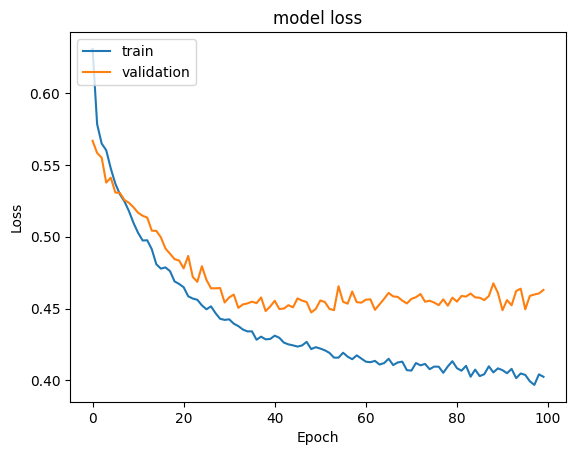

```python
# Plot Train Loss vs Validation Loss
plt.plot(history_5.history['loss'])
plt.plot(history_5.history['val_loss'])
plt.title('model loss')
plt.ylabel('Loss')
plt.xlabel('Epoch')
plt.legend(['train', 'validation'], loc='upper left')
plt.show()
```

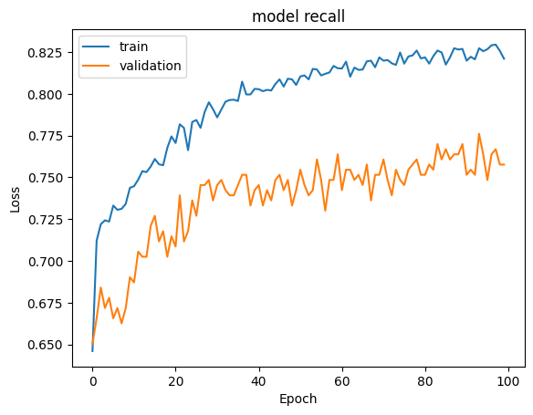

```python
# Plot Train recall vs Validation recall
plt.plot(history_5.history['recall'])
plt.plot(history_5.history['val_recall'])
plt.title('model recall')
plt.ylabel('Loss')
plt.xlabel('Epoch')
plt.legend(['train', 'validation'], loc='upper left')
plt.show()
```

```python
# Predict SMOTE train results using 0.5 as the threshold
y_train_pred = model_5.predict(X_train_smote)
y_train_pred = (y_train_pred > 0.5)
y_train_pred
```

```
319/319 ━━━━━━━━━━━━━━━━━━━━ 1s 2ms/step
```

```
array([[ True],
       [False],
       [False],
       ...,
       [ True],
       [ True],
       [ True]])
```

```python
# Predict validation results using 0.5 as the threshold
y_val_pred = model_5.predict(X_val)
y_val_pred = (y_val_pred > 0.5)
y_val_pred
```

```
50/50 ━━━━━━━━━━━━━━━━━━━━ 0s 2ms/step
```

```
array([[False],
       [False],
       [False],
       ...,
       [False],
       [ True],
       [ True]])
```

```python
# Establish model name
model_name = "NN with SMOTE,Adam & Dropout"
train_metric_df.loc[model_name] = recall_score(y_train_smote,y_train_pred)
valid_metric_df.loc[model_name] = recall_score(y_val,y_val_pred)
```

**Classification report**

```python
# Show SMOTE train classification report
cr=classification_report(y_train_smote,y_train_pred)
print(cr)
```

```
              precision    recall  f1-score   support

           0       0.86      0.80      0.83      5096
           1       0.81      0.87      0.84      5096

    accuracy                           0.84     10192
   macro avg       0.84      0.84      0.84     10192
weighted avg       0.84      0.84      0.84     10192
```

```python
# Show validation classification report
cr=classification_report(y_val,y_val_pred)
print(cr)
```

```
              precision    recall  f1-score   support

           0       0.93      0.79      0.85      1274
           1       0.48      0.76      0.59       326

    accuracy                           0.79      1600
   macro avg       0.70      0.77      0.72      1600
weighted avg       0.84      0.79      0.80      1600
```

**Confusion matrix**

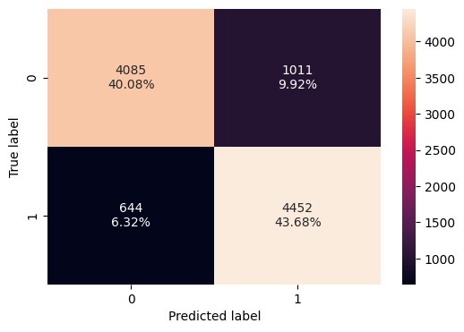

```python
# Show SMOTE train confusion matrix
make_confusion_matrix(y_train_smote, y_train_pred)
```

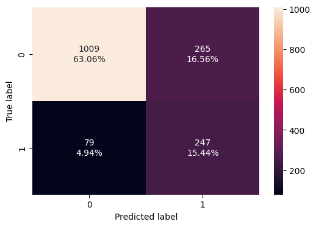

```python
# Show validation confusion matrix
make_confusion_matrix(y_val,y_val_pred)
```

## Model Performance Comparison and Final Model Selection

```python
# Show train model performance comparison
print("Training performance comparison")
train_metric_df
```

```
Training performance comparison
```

|  | recall |
| --- | --- |
| NN with SGD | 0.128067 |
| NN with Adam | 0.446319 |
| NN with Adam & Dropout | 0.554448 |
| NN with SMOTE & SGD | 0.730181 |
| NN with SMOTE & Adam | 0.908752 |
| NN with SMOTE,Adam & Dropout | 0.873626 |

```python
# Show validation model performance comparison
print("Validation set performance comparison")
valid_metric_df
```

```
Validation set performance comparison
```

|  | recall |
| --- | --- |
| NN with SGD | 0.092025 |
| NN with Adam | 0.358896 |
| NN with Adam & Dropout | 0.472393 |
| NN with SMOTE & SGD | 0.693252 |
| NN with SMOTE & Adam | 0.726994 |
| NN with SMOTE,Adam & Dropout | 0.757669 |

```python
# Show difference between train and validation performance comparison
train_metric_df - valid_metric_df
```

|  | recall |
| --- | --- |
| NN with SGD | 0.036043 |
| NN with Adam | 0.087423 |
| NN with Adam & Dropout | 0.082055 |
| NN with SMOTE & SGD | 0.036929 |
| NN with SMOTE & Adam | 0.181758 |
| NN with SMOTE,Adam & Dropout | 0.115958 |

```python
# Fit optimal/best model to the test set
y_test_pred = model_5.predict(X_test)
y_test_pred = (y_test_pred > 0.5)
print(y_test_pred)
```

```
63/63 ━━━━━━━━━━━━━━━━━━━━ 0s 2ms/step
[[False]
 [False]
 [False]
 ...
 [ True]
 [False]
 [False]]
```

```python
# Show test classification report
cr=classification_report(y_test,y_test_pred)
print(cr)
```

```
              precision    recall  f1-score   support

           0       0.93      0.77      0.84      1593
           1       0.46      0.77      0.58       407

    accuracy                           0.77      2000
   macro avg       0.69      0.77      0.71      2000
weighted avg       0.83      0.77      0.79      2000
```

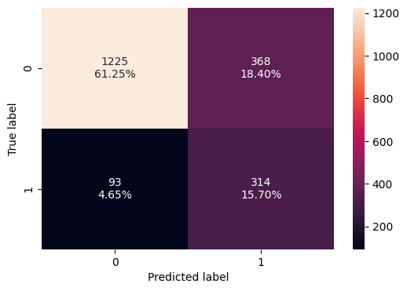

```python
# Show test confusion matrix
make_confusion_matrix(y_test,y_test_pred)
```

## Actionable Insights and Business Recommendations

Insights:

- Inactive members have an extremely high churn rate and make up a high proportion of the analyzed dataset.
- Age is an important factor of customers churning. This occurrence is more than likely due to different marketing preferences.
- The analysis also highlights that female customers have a higher churn rate compared to male customers.
- It appears that older costumers churn more frequently compared to younger customers.
- Tenure is a major indicator for customers churing. Costumers with long tenure or very short tenure have a higher probablilty of churning compared to costumers that have an average tenure.

Recommendations:

- Develop a marketing strategy that focuses on converting inactive members to active members which could have a high positive impact on churn rates.
- Develop a marketing strategy that gives incentives to female customers to encourage retention.
- Incentivize indiviudals based on tenure. For example, give initial sign up bonuses and/or cash advances at different tenure levels (i.e., 5 years, 10 years, etc.)
- Ensure that marketing strategies are properly adjusted to respective target audiences. For example, older generations are more than likely susceptible to traditional media sources (Radio, Television, Mail), whereas younger generations will more than likely respond better to social media marketing.